# Paveethran_Assignment1

```python
# Q1:
import torchvision
import numpy as np
from sklearn.metrics import accuracy_score
import torch
import torch.nn as nn
import torch.optim as optim
import torch.nn.functional as func
from torchvision import transforms, datasets
from torch.utils.data import SubsetRandomSampler, RandomSampler, random_split
import matplotlib.pyplot as plt

mnist_train=torchvision.datasets.MNIST('mnist',
                train=True,
                download=True,
                transform=torchvision.transforms.Compose([
                torchvision.transforms.ToTensor(),
                torchvision.transforms.Normalize((0.1307,), (0.3081,))
                ]))

# Get validation split here (5000 random samples as validation data)
# mnist_valid = random_split(mnist_train, [len(mnist_train) - 5000, 5000])
# dataset_size = len(mnist_train)
# indices = list(range(dataset_size))
# validation_split = 0.2
# split = int(validation_split * dataset_size)
# np.random.shuffle(indices)
# train_indices, val_indices = indices[split:], indices[:split]

# # # Creating PT data samplers and loaders:
# train_sampler = SubsetRandomSampler(train_indices)
# valid_sampler = SubsetRandomSampler(val_indices)

mnist_test=torchvision.datasets.MNIST('mnist',
                train=False,
                download=True,
                transform=torchvision.transforms.Compose([
                torchvision.transforms.ToTensor(),
                torchvision.transforms.Normalize((0.1307,), (0.3081,))
                ]))

print(type(mnist_train))
```

```
<class 'torchvision.datasets.mnist.MNIST'>
```

```python
batch_size_train = 128 # batch size train set
batch_size_test = 128 # batch size test set

print(mnist_train.data.shape)
print(mnist_test.data.shape)
print(len(mnist_test))
```

```
torch.Size([60000, 28, 28])
torch.Size([10000, 28, 28])
10000
```

```python
# Dataloader for laoding in data
# Steps to do this is to convert raw data to tensor
# Then tensor to dataset object
# And then from dataset object to dataloader

# Our MNIST is already in tensorDataset format
train_loader = torch.utils.data.DataLoader(dataset=mnist_train,
                                             batch_size=batch_size_train,
                                             shuffle=True)
valid_loader = torch.utils.data.DataLoader(dataset=mnist_test,
                                             batch_size=batch_size_test,
                                             shuffle=False)

# First split trainset into train and validation data
# train_loader = torch.utils.data.DataLoader(mnist_train, batch_size=5000, sampler=train_sampler)
# valid_loader = torch.utils.data.DataLoader(mnist_train, batch_size=len(val_indices), sampler=valid_sampler)

# Same for test dataset
# testset = torch.utils.data.DataLoader(mnist_test, batch_size=len(mnist_test), shuffle=False)
```

```python
# Get device
if(torch.cuda.is_available()):
    device = torch.device('cuda')

print(f"Using {device} device")
print(torch.cuda.get_device_name(0))

# Set torch random seed
torch.manual_seed(100)
np.random.seed(100)
```

```
Using cuda device
NVIDIA GeForce GTX 1650 Ti
```

```python
class NN(nn.Module):

    def __init__(self):
        super().__init__() # any init calls before this should also call this init only
        self.fp_input = nn.Linear(28*28, 1024)
        self.fp1 = nn.Linear(1024, 1024)
        self.fp2 = nn.Linear(1024, 1024)
        self.fp3 = nn.Linear(1024, 1024)
        self.fp4 = nn.Linear(1024, 1024)
        self.fp5 = nn.Linear(1024, 1024)
        self.fp_output = nn.Linear(1024, 10)
        self.dropout = nn.Dropout(0.2)
        self.ReLU = nn.ReLU()
#         self.output_activation = nn.softmax(dim = 1)

    def forward(self, input):
        to_save_layerop = {}

        # flatten input already so that it is a row vector
        input = self.fp_input(input)
#         input = func.leaky_relu(input)
        input = self.ReLU(input)
        to_save_layerop['fp_input'] = input

        input = self.fp1(input)
        input = self.ReLU(input)
        to_save_layerop['fp1'] = input

        input = self.fp2(input)
        input = self.ReLU(input)
#         input - self.dropout(input)
        to_save_layerop['fp2'] = input

        input = self.fp3(input)
        input = self.ReLU(input)
        to_save_layerop['fp3'] = input

        input = self.fp4(input)
        input = self.ReLU(input)
#         input - self.dropout(input)
        to_save_layerop['fp4'] = input

        input = self.fp5(input)
        input = self.ReLU(input)
        to_save_layerop['fp5'] = input

        input = self.fp_output(input)
        to_save_layerop['fp_output_before_softmax'] = input
# MOST IMPORTANT REALIZATION...USE SOFTMAX AFTER CALCULATING CCE LOSS, THE CCE LOSS EXPECTS LOGITS AND NOT SOFTMAX OUTPUTS.
#         input = func.softmax(input, dim = 1)
        return input, to_save_layerop
```

```python
#Uniform initialization
def weights_init_uniform_rule(m):
    if isinstance(m, nn.Linear):
        n = m.in_features # number of inputs
        y = 1.0/np.sqrt(n)
        m.weight.data.uniform_(-y, y)
        m.bias.data.fill_(0)


def xavier_weights(m):
    if isinstance(m, nn.Linear):
        torch.nn.init.xavier_uniform_(m.weight)
        m.bias.data.fill_(0.01)

def he_weights(m):
    if isinstance(m, nn.Linear):
        torch.nn.init.kaiming_uniform_(m.weight, a=0, mode='fan_in', nonlinearity='relu')
#         print(m.weight)
        m.bias.data.fill_(0.01)
```

```python
def create_and_run_network(lr, epochs):
    # A minor difference is that the implementation of CrossEntrypyLoss implicitly applies a softmax activation followed by a log transformation
    # but NLLLoss does not.
    net = NN().to(device)
    net.apply(weights_init_uniform_rule)
    optimizer = torch.optim.Adam(net.parameters(), lr = 0.001)
    loss_func = nn.CrossEntropyLoss()
#     optimizer = torch.optim.SGD(net1.parameters(), lr = 0.001)

    train_loss_all = []
    valid_loss_all = []

    # To keep best performance accuracy
    max_performance = -999

    # For early stopping
    tolerance_level = 0
    early_stopping_activated = 0
    epoch = 1

    while( epoch <= epochs and early_stopping_activated == 0 ):
        train_loss = 0
        valid_loss = 0

        # Always have this line to ensure proper training
        net.train()

        for i, (data, labels) in enumerate(train_loader):
            data = data.reshape(-1, 784)

            # Push all variables to cuda
            if(torch.cuda.is_available()):
                data, labels =  data.to(device), labels.to(device)

            output, inter_op = net(data)
            loss = loss_func(output, labels)

            optimizer.zero_grad() # reset gradients
            loss.backward()
            optimizer.step()

            # Track loss
            train_loss += loss.item()

        # Always have this line to ensure proper evaluation
        net.eval()

        actual_labels_all = []
        pred_labels_all = []
        # Now do validation and keep track of valid loss
        with torch.no_grad():
            for i, (data, labels) in enumerate(valid_loader):
                data = data.reshape(-1, 784)

                if(torch.cuda.is_available()):
                    data, labels = data.to(device), labels.to(device)

                # FP
                val_labels_pred_logits, inter_op = net.forward(data)

                v_loss = loss_func(val_labels_pred_logits, labels)
                valid_loss += v_loss.item()

                val_labels_pred_logits = func.softmax(val_labels_pred_logits, dim = 1)
                val_labels_pred_digits = val_labels_pred_logits.argmax(dim=1, keepdim=True)

                actual_labels_all.append(labels.cpu().numpy())
                pred_labels_all.append(val_labels_pred_digits.cpu().numpy())


        all_preds = np.concatenate(pred_labels_all, axis=0)
        all_targets = np.concatenate(actual_labels_all, axis=0)
        performance = accuracy_score( all_preds, all_targets)

        if(epoch % 5 == 0):
            print(f'Epoch {epoch} \t\t Training loss: {train_loss/len(mnist_train)} \t\t Validation loss: {valid_loss/len(mnist_test)} \
            Validation Accuracy: {performance*100} %')

        train_loss_all.append(train_loss/len(mnist_train))
        valid_loss_all.append(valid_loss/len(mnist_test))

        epoch+=1

        if(performance*100 > max_performance):
            max_performance = performance*100
            tolerance_level = 0
            # Save Model
            MAX_PERFORMANCE_WEIGHTS = net.state_dict()

        else:
            tolerance_level+=1
            if(tolerance_level >= 10):
                early_stopping_activated = 1
                print('Early Stopping activated - no improvement in validation accuracy for the past 10 epochs. Using model stage before 10 epochs for further use.')

    print('Best Performance on Validation set(Same as Test data here) achived till now :', max_performance)

    return net, MAX_PERFORMANCE_WEIGHTS
```

```python
# Calling the NN class
epochs = 50
model_net, MAX_PERFORMANCE_WEIGHTS = create_and_run_network(lr=0.001, epochs = epochs)
```

```
Epoch 5 		 Training loss: 0.0005592840879806317 		 Validation loss: 0.0007312656790141773             Validation Accuracy: 97.92 %
Epoch 10 		 Training loss: 0.00030714964135077023 		 Validation loss: 0.0008494775086472544             Validation Accuracy: 97.74000000000001 %
Epoch 15 		 Training loss: 0.00021587343902920112 		 Validation loss: 0.0009721049508593353             Validation Accuracy: 97.72999999999999 %
Epoch 20 		 Training loss: 0.0001758782601312305 		 Validation loss: 0.000967391132353805             Validation Accuracy: 97.34 %
Epoch 25 		 Training loss: 0.00011379209199111528 		 Validation loss: 0.0010319955043810098             Validation Accuracy: 98.25 %
Early Stopping activated - no improvement in validation accuracy for the past 10 epochs. Using model stage before 10 epochs for further use.
Best Performance on Validation set(Same as Test data here) achived till now : 98.34
```

```python
# Save and load model weights
# torch.save(model_net, 'Model Prob1 Net')
# torch.save(MAX_PERFORMANCE_WEIGHTS, 'Final Model Q1')
net = NN().to(device)
net.load_state_dict(torch.load('Final Model Q1'))
```

```
<All keys matched successfully>
```

### Testing the accuracy on test data

```python
# Always have this line to ensure proper evaluation
net.eval()

actual_labels_all = []
pred_labels_all = []
# Now do validation and keep track of valid loss
with torch.no_grad():
    for i, (data, labels) in enumerate(valid_loader):
        data = data.reshape(-1, 784)

        if(torch.cuda.is_available()):
            data, labels = data.to(device), labels.to(device)

        # FP
        val_labels_pred_logits, inter_op = net.forward(data)

        val_labels_pred_logits = func.softmax(val_labels_pred_logits, dim = 1)
        val_labels_pred_digits = val_labels_pred_logits.argmax(dim=1, keepdim=True)

        actual_labels_all.append(labels.cpu().numpy())
        pred_labels_all.append(val_labels_pred_digits.cpu().numpy())

all_preds = np.concatenate(pred_labels_all, axis=0)
all_targets = np.concatenate(actual_labels_all, axis=0)
performance = accuracy_score( all_preds, all_targets)

print(' Accuracy on Test dataset : ', performance*100 ,' %')
```

```
 Accuracy on Test dataset :  98.3  %
```

#### Accuracy is more than 98%

## Problem 1.3

```python
# For all other problems, do valid loader without batch processing
valid_loader = torch.utils.data.DataLoader(dataset=mnist_test,
                                             batch_size=len(mnist_test),
                                             shuffle=False)
```

```python
# Get the softmax layer output
with torch.no_grad():
    for i, (data, labels) in enumerate(valid_loader):
        flat_data = data.reshape(-1, 784).to(device)
        val_labels_pred_logits, inter_op = net.forward(flat_data)
        softmax_output = func.softmax(val_labels_pred_logits, dim = 1)
```

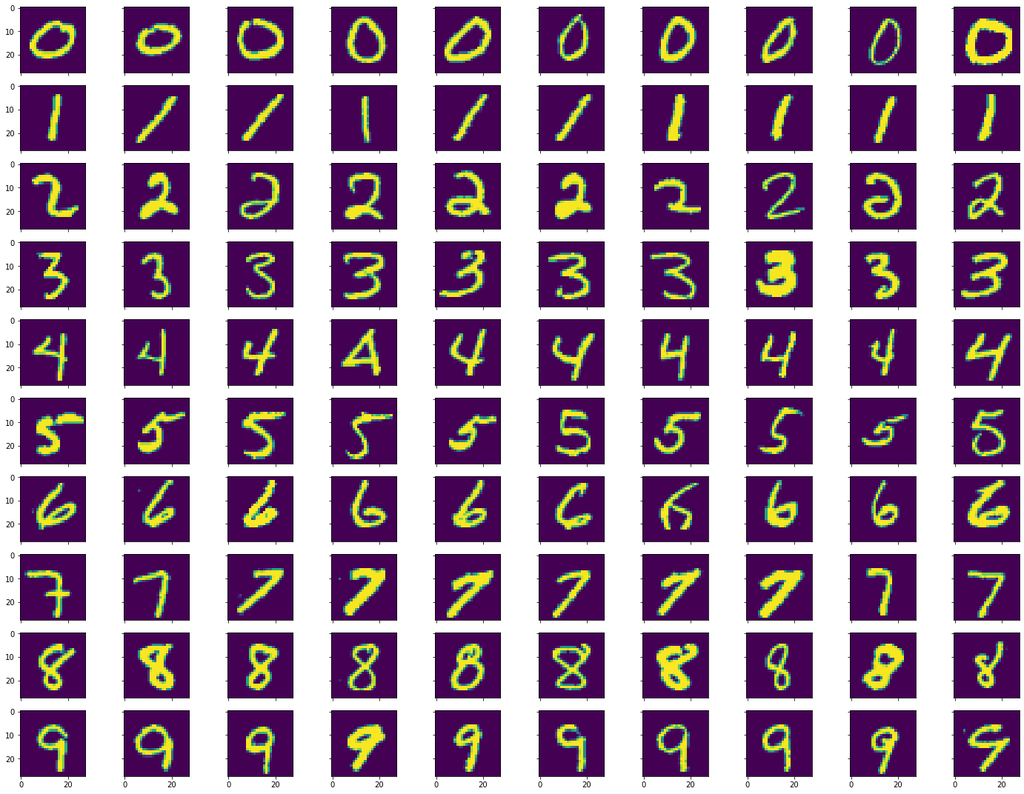

```python
fig, axes = plt.subplots(10, 10, sharex=True, sharey=True, figsize = (20,15) )

for i in range(10):
    # for each digit, get the top 10 data points which have hightest activations for that digit's index
    zerodigit_prob_samples = softmax_output[:,i].cpu().numpy()
    max_prob_samples_index = (zerodigit_prob_samples).argsort()[-10:]

    for j in range(len(max_prob_samples_index)):
        ax = axes[i, j]
        ax.imshow(data.cpu().numpy()[max_prob_samples_index[j]][0])

plt.tight_layout()
```

## Problem 1.4

```python
# Re-defined network to store intermediate layer outputs and use old (pretrained) weights to do forward pass
# Calling the NN class
# model_net_re = NN().to(device)
# model_net_re.load_state_dict(model_net.state_dict())
# print(model_net_re)
```

[output not shown]

```python
sc_hidden_activations = inter_op['fp5'][:,np.random.choice(np.array(range(0,1024)),10,replace=False)]
sc_hidden_activations = sc_hidden_activations[np.random.choice(np.array(range(0,10000)),1000,replace=False)]

print('Second last Hidden Layer Activations: ', sc_hidden_activations.shape)

# pass through softmax and get the information of whichdigit neurons are activated (some may be and some may not be)
sc_preds = func.softmax(sc_hidden_activations, dim = 1).argmax(1).cpu().numpy()
print(sc_preds.shape)
```

```
Second last Hidden Layer Activations:  torch.Size([1000, 10])
(1000,)
```

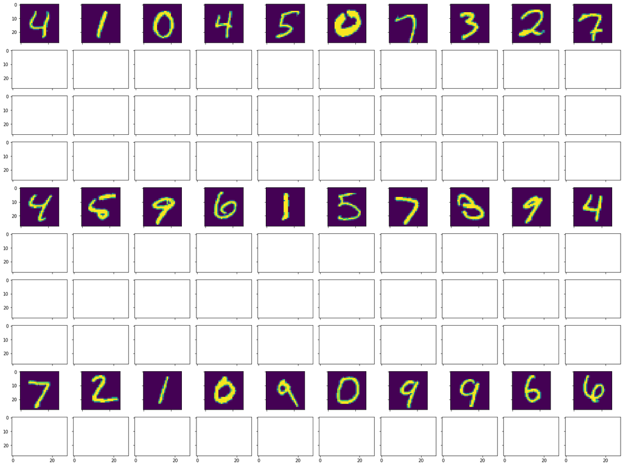

```python
fig, axes = plt.subplots(10, 10, sharex=True, sharey=True, figsize = (20,15) )

for i in range(10):
    # for each digit, get the top 10 data points which have highest activations for that digit's index
    max_prob_samples_index = np.where(sc_preds== i)[0][:10]
    if(len(max_prob_samples_index) > 0 ):
        for j in range(0,10):
            ax = axes[i, j]
            try:
                ax.imshow(data.cpu().numpy()[max_prob_samples_index[j]][0])
            except:
                pass


plt.tight_layout()
```

#### We can see that in 1.4 there are many empty cells and in those cells which have an image, it's mostly wrong and does not match with correct label. This is because the activation output from second to last layer was was not trained to give the main output for this network, this was just an input to another layer which was trained to be the output layer with 10 neurons. In 1.3, we had taken the trained values of feature embedding, and these represent the logits for passing into the final softmax activation, where we can get the predicted labels. But this second to last layer was just an input, with each neuron giving out it's own learned feature representation of the image. And even from there, we are randomly taking activated neurons, which is most definitely not going to give us correct images. The second to last layer can be trained on another neural network with just one or few hidden layers to give us correct output, or even use this as an input to a simple classfication model and that can give us correct predicted labels. Also, if had trained by assuming this layer to be the final layer, we should change the activation function from relu to softmax (or sigmoid if using binary classifier). That can also give us correct predicted images.

## Problem 1.5

```python
# Using t-SNE
from sklearn.manifold import TSNE
from sklearn.preprocessing import StandardScaler
from sklearn.decomposition import PCA
import pandas as pd

x = mnist_test.data[:1000].reshape(-1, 784).cpu().numpy()
y = mnist_test.targets[:1000].cpu().numpy()

# TO obtain TSNE embedding from 784 dimensions to 2 dimensions
n_components = 2
tsne = TSNE(n_components)
tsne_op = tsne.fit_transform(x)

# scale data before pca - sensitive to scaling (covariance is dependent on scale of variables)
# x_scaled = StandardScaler().fit_transform(x)
# No need to scale now, as input data is already normalized
pca = PCA(n_components=2)
pca_op = pca.fit_transform(x)
```

```python
print(pca_op.shape, tsne_op.shape)

# To label centers with label values, we need means of x and y values of every label group
label_means = []
for i in range(10):
    pm = np.where(y==i)
    label_means.append( (tsne_op[pm,0].mean(), tsne_op[pm,1].mean()) )

print(len(label_means))
```

```
(1000, 2) (1000, 2)
10
```

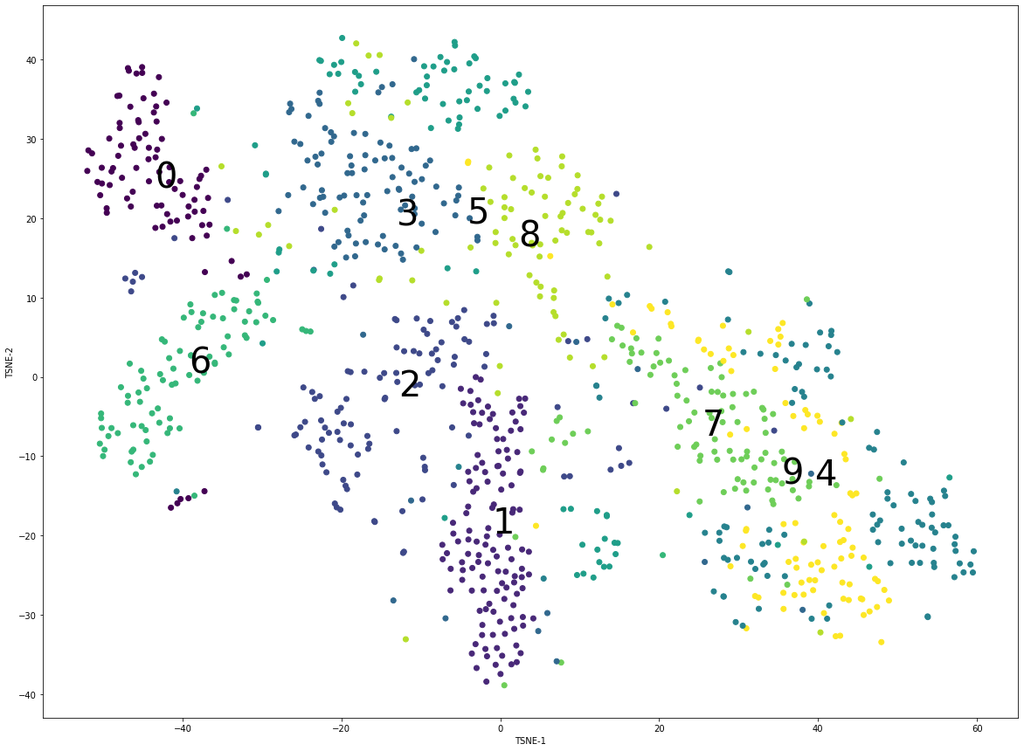

```python
plt.figure(figsize=(20,15))
plt.scatter(x = tsne_op[:,0], y = tsne_op[:,1], c=y)
for i in range(10):
    plt.text(x = label_means[i][0], y = label_means[i][1], s = str(i), fontsize = 40)
plt.xlabel('TSNE-1')
plt.ylabel('TSNE-2')
plt.show()
```

```python
# To label centers with label values, we need means of x and y values of every label group
label_means = []
for i in range(10):
    pm = np.where(y==i)
    label_means.append( (pca_op[pm,0].mean(), pca_op[pm,1].mean()) )
```

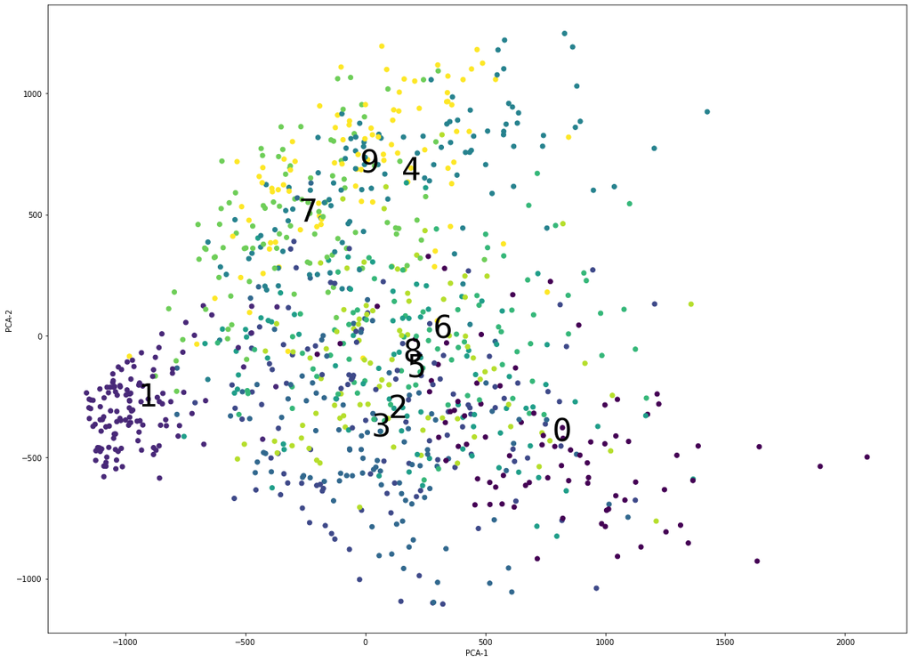

```python
plt.figure(figsize=(20,15))
plt.scatter(x = pca_op[:,0], y = pca_op[:,1], c=y)
for i in range(10):
    plt.text(x = label_means[i][0], y = label_means[i][1], s = str(i), fontsize = 40)
plt.xlabel('PCA-1')
plt.ylabel('PCA-2')
plt.show()
```

#### Explanation for Raw Image graphs:

#### When we use raw image pixel values for dimensionality reduction and plotting the scatter plot, we can see it's not easy to distinguish cliusters and classify points as different labels. There is so much overlap in many points and it's not easily classifiable. With tSNE, atleast a few numbers can be seen as separate clusters, but majority of the digits are overlapped. And it is even worse for PCA, there is no separation among the points, and we can not see the principal components, or the eigen vectors that provide most variance information in the data.

### Trying UMAP - should give better results

```python
from umap import UMAP
umap = UMAP(n_components=2, init='random', random_state=0)
umap_op = umap.fit_transform(x)
```

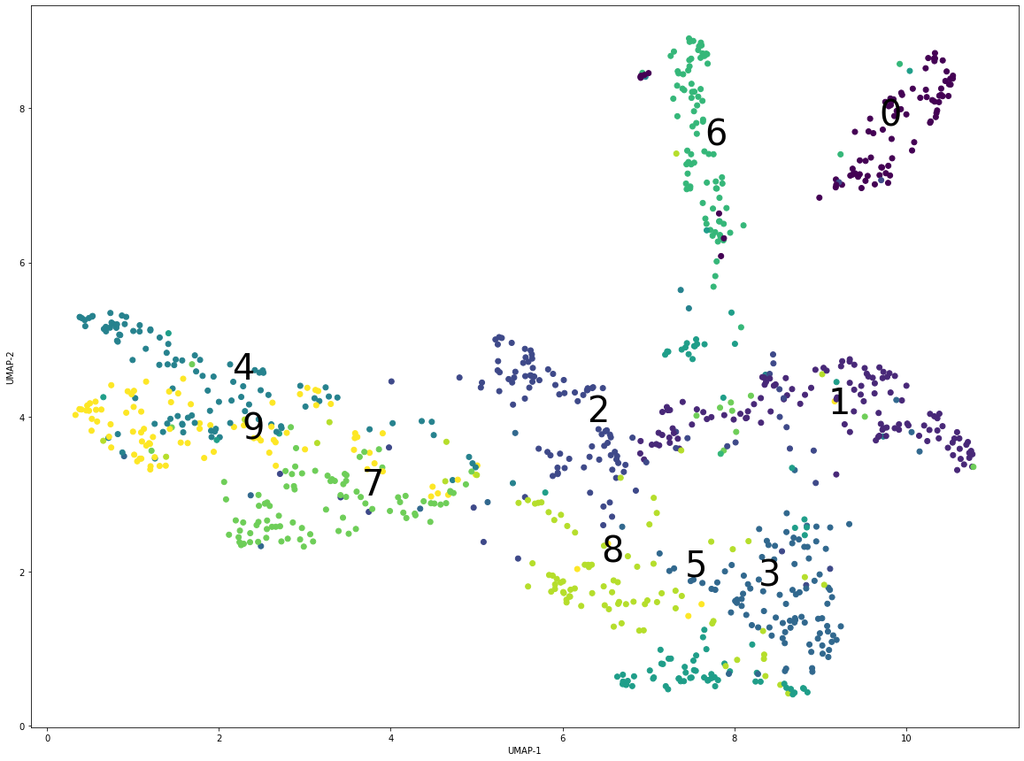

```python
# To label centers with label values, we need means of x and y values of every label group
label_means = []
for i in range(10):
    pm = np.where(y==i)
    label_means.append( (umap_op[pm,0].mean(), umap_op[pm,1].mean()) )

plt.figure(figsize=(20,15))
plt.scatter(x = umap_op[:,0], y = umap_op[:,1], c=y)
for i in range(10):
    plt.text(x = label_means[i][0], y = label_means[i][1], s = str(i), fontsize = 40)
plt.xlabel('UMAP-1')
plt.ylabel('UMAP-2')
plt.show()
```

## Problem 1.7

### FIRST HIDDEN LAYER

```python
# Get output of first hidden layer
# Now do forward pass and get outputs
# Get the softmax layer output
with torch.no_grad():
    for i, (data, labels) in enumerate(valid_loader):
        labels = labels[:1000]
        data = data[:1000].to(device)
        softmax_output, inter_op = net.forward(data.reshape(-1, 784))
#         softmax_output = func.softmax(val_labels_pred_logits, dim = 1)
```

```python
first_hidden = inter_op['fp1']
print(first_hidden.shape)

# Using t-SNE
from sklearn.manifold import TSNE
from sklearn.preprocessing import StandardScaler
from sklearn.decomposition import PCA
import pandas as pd

# x = mnist_test.data[:1000].reshape(-1, 784).cpu().numpy()
# y = mnist_test.targets[:1000].cpu().numpy()

x = first_hidden.cpu().detach().numpy()
y = labels.cpu().numpy()

# TO obtain TSNE embedding from 784 dimensions to 2 dimensions
n_components = 2
tsne = TSNE(n_components)
tsne_op = tsne.fit_transform(x)

# scale data before pca - sensitive to scaling (covariance is dependent on scale of variables)
# x_scaled = StandardScaler().fit_transform(x)
# No need to scale now, as input data is already normalized
pca = PCA(n_components=2)
pca_op = pca.fit_transform(x)
```

```
torch.Size([1000, 1024])
```

```
(1000, 2) (1000, 2)
10
```

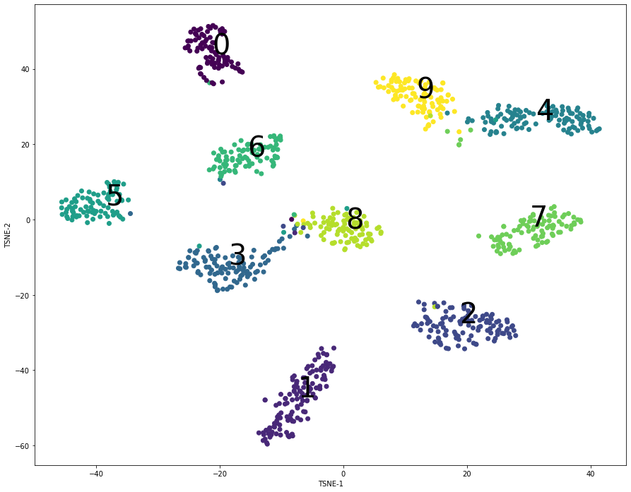

```python
print(pca_op.shape, tsne_op.shape)

# To label centers with label values, we need means of x and y values of every label group
label_means = []
for i in range(10):
    pm = np.where(y==i)
    label_means.append( (tsne_op[pm,0].mean(), tsne_op[pm,1].mean()) )

print(len(label_means))

plt.figure(figsize=(15,12))
plt.scatter(x = tsne_op[:,0], y = tsne_op[:,1], c=y)
for i in range(10):
    plt.text(x = label_means[i][0], y = label_means[i][1], s = str(i), fontsize = 40)
plt.xlabel('TSNE-1')
plt.ylabel('TSNE-2')
plt.show()
```

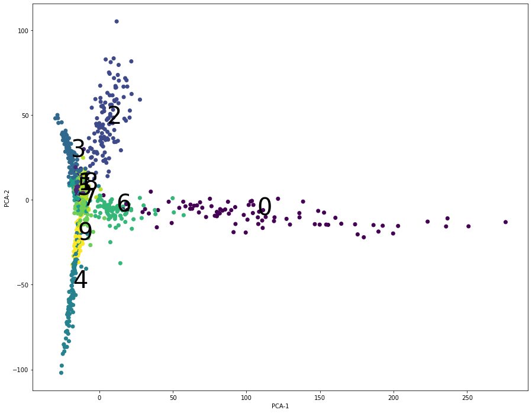

```python
# To label centers with label values, we need means of x and y values of every label group
label_means = []
for i in range(10):
    pm = np.where(y==i)
    label_means.append( (pca_op[pm,0].mean(), pca_op[pm,1].mean()) )


plt.figure(figsize=(15,12))
plt.scatter(x = pca_op[:,0], y = pca_op[:,1], c=y)
for i in range(10):
    plt.text(x = label_means[i][0], y = label_means[i][1], s = str(i), fontsize = 40)
plt.xlabel('PCA-1')
plt.ylabel('PCA-2')
plt.show()
```

### SECOND HIDDEN LAYER

```python
# Get output of second hidden layer

first_hidden = inter_op['fp2']
print(first_hidden.shape)

# Using t-SNE
from sklearn.manifold import TSNE
from sklearn.preprocessing import StandardScaler
from sklearn.decomposition import PCA
import pandas as pd

# x = mnist_test.data[:1000].reshape(-1, 784).cpu().numpy()
# y = mnist_test.targets[:1000].cpu().numpy()

x = first_hidden.cpu().detach().numpy()
print(x.shape)
y = labels.cpu().numpy()

# TO obtain TSNE embedding from 784 dimensions to 2 dimensions
n_components = 2
tsne = TSNE(n_components)
tsne_op = tsne.fit_transform(x)

# scale data before pca - sensitive to scaling (covariance is dependent on scale of variables)
# x_scaled = StandardScaler().fit_transform(x)
# No need to scale now, as input data is already normalized
pca = PCA(n_components=2)
pca_op = pca.fit_transform(x)
```

```
torch.Size([1000, 1024])
(1000, 1024)
```

```
(1000, 2) (1000, 2)
10
```

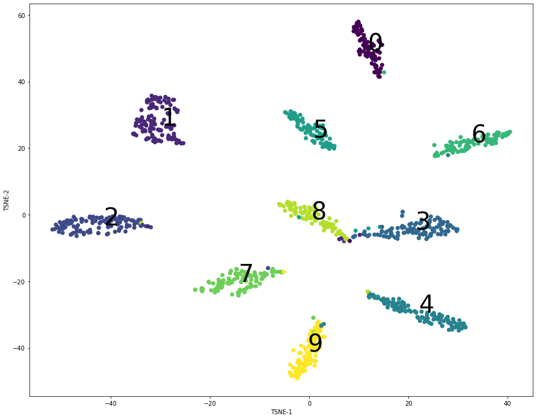

```python
print(pca_op.shape, tsne_op.shape)

# To label centers with label values, we need means of x and y values of every label group
label_means = []
for i in range(10):
    pm = np.where(y==i)
    label_means.append( (tsne_op[pm,0].mean(), tsne_op[pm,1].mean()) )

print(len(label_means))

plt.figure(figsize=(15,12))
plt.scatter(x = tsne_op[:,0], y = tsne_op[:,1], c=y)
for i in range(10):
    plt.text(x = label_means[i][0], y = label_means[i][1], s = str(i), fontsize = 40)
plt.xlabel('TSNE-1')
plt.ylabel('TSNE-2')
plt.show()
```

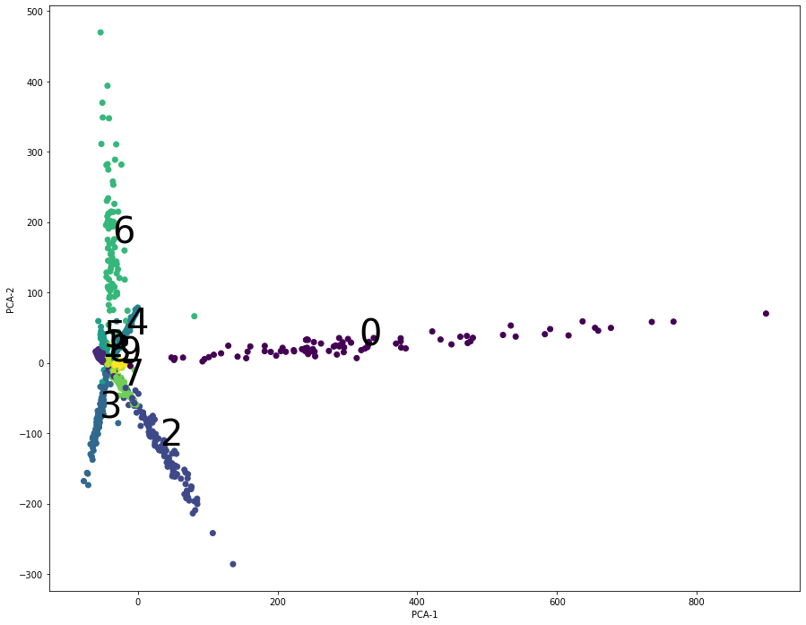

```python
# To label centers with label values, we need means of x and y values of every label group
label_means = []
for i in range(10):
    pm = np.where(y==i)
    label_means.append( (pca_op[pm,0].mean(), pca_op[pm,1].mean()) )


plt.figure(figsize=(15,12))
plt.scatter(x = pca_op[:,0], y = pca_op[:,1], c=y)
for i in range(10):
    plt.text(x = label_means[i][0], y = label_means[i][1], s = str(i), fontsize = 40)
plt.xlabel('PCA-1')
plt.ylabel('PCA-2')
plt.show()
```

### THIRD HIDDEN LAYER

```python
# Get output of third hidden layer

first_hidden = inter_op['fp3']
print(first_hidden.shape)

# Using t-SNE
from sklearn.manifold import TSNE
from sklearn.preprocessing import StandardScaler
from sklearn.decomposition import PCA
import pandas as pd

# x = mnist_test.data[:1000].reshape(-1, 784).cpu().numpy()
# y = mnist_test.targets[:1000].cpu().numpy()

x = first_hidden.cpu().detach().numpy()
print(x.shape)
y = labels.cpu().numpy()

# TO obtain TSNE embedding from 784 dimensions to 2 dimensions
n_components = 2
tsne = TSNE(n_components)
tsne_op = tsne.fit_transform(x)

# scale data before pca - sensitive to scaling (covariance is dependent on scale of variables)
# x_scaled = StandardScaler().fit_transform(x)
# No need to scale now, as input data is already normalized
pca = PCA(n_components=2)
pca_op = pca.fit_transform(x)
```

```
torch.Size([1000, 1024])
(1000, 1024)
```

```
(1000, 2) (1000, 2)
10
```

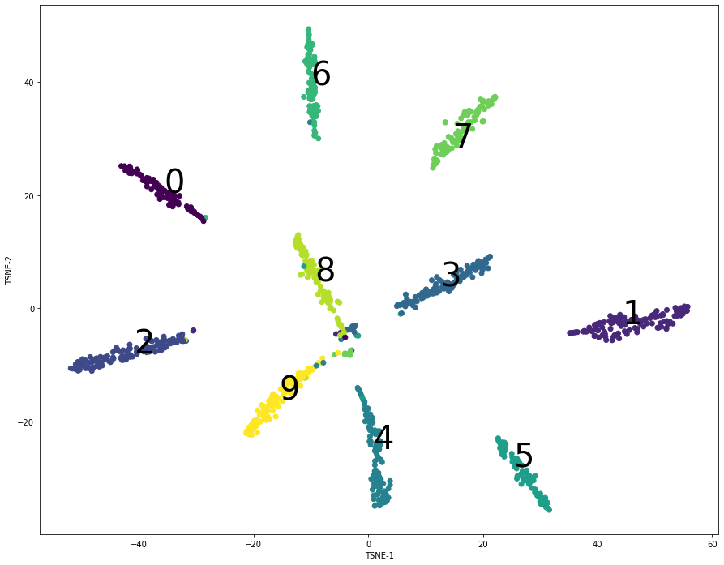

```python
print(pca_op.shape, tsne_op.shape)

# To label centers with label values, we need means of x and y values of every label group
label_means = []
for i in range(10):
    pm = np.where(y==i)
    label_means.append( (tsne_op[pm,0].mean(), tsne_op[pm,1].mean()) )

print(len(label_means))

plt.figure(figsize=(15,12))
plt.scatter(x = tsne_op[:,0], y = tsne_op[:,1], c=y)
for i in range(10):
    plt.text(x = label_means[i][0], y = label_means[i][1], s = str(i), fontsize = 40)
plt.xlabel('TSNE-1')
plt.ylabel('TSNE-2')
plt.show()
```

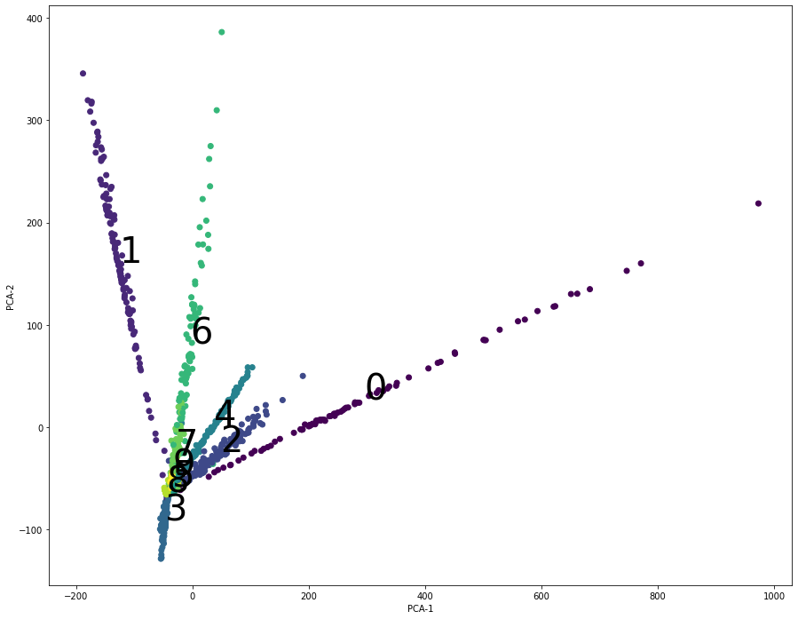

```python
# To label centers with label values, we need means of x and y values of every label group
label_means = []
for i in range(10):
    pm = np.where(y==i)
    label_means.append( (pca_op[pm,0].mean(), pca_op[pm,1].mean()) )


plt.figure(figsize=(15,12))
plt.scatter(x = pca_op[:,0], y = pca_op[:,1], c=y)
for i in range(10):
    plt.text(x = label_means[i][0], y = label_means[i][1], s = str(i), fontsize = 40)
plt.xlabel('PCA-1')
plt.ylabel('PCA-2')
plt.show()
```

### FOURTH HIDDEN LAYER

```python
# Get output of fourth hidden layer

first_hidden = inter_op['fp4']
print(first_hidden.shape)

# Using t-SNE
from sklearn.manifold import TSNE
from sklearn.preprocessing import StandardScaler
from sklearn.decomposition import PCA
import pandas as pd

# x = mnist_test.data[:1000].reshape(-1, 784).cpu().numpy()
# y = mnist_test.targets[:1000].cpu().numpy()

x = first_hidden.cpu().detach().numpy()
print(x.shape)
y = labels.cpu().numpy()

# TO obtain TSNE embedding from 784 dimensions to 2 dimensions
n_components = 2
tsne = TSNE(n_components)
tsne_op = tsne.fit_transform(x)

# scale data before pca - sensitive to scaling (covariance is dependent on scale of variables)
# x_scaled = StandardScaler().fit_transform(x)
# No need to scale now, as input data is already normalized
pca = PCA(n_components=2)
pca_op = pca.fit_transform(x)
```

```
torch.Size([1000, 1024])
(1000, 1024)
```

```
(1000, 2) (1000, 2)
10
```

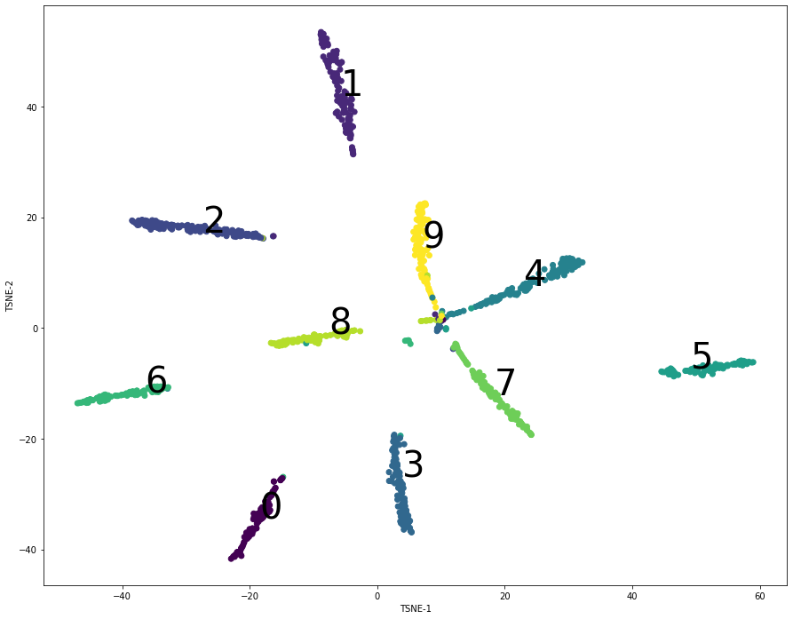

```python
print(pca_op.shape, tsne_op.shape)

# To label centers with label values, we need means of x and y values of every label group
label_means = []
for i in range(10):
    pm = np.where(y==i)
    label_means.append( (tsne_op[pm,0].mean(), tsne_op[pm,1].mean()) )

print(len(label_means))

plt.figure(figsize=(15,12))
plt.scatter(x = tsne_op[:,0], y = tsne_op[:,1], c=y)
for i in range(10):
    plt.text(x = label_means[i][0], y = label_means[i][1], s = str(i), fontsize = 40)
plt.xlabel('TSNE-1')
plt.ylabel('TSNE-2')
plt.show()
```

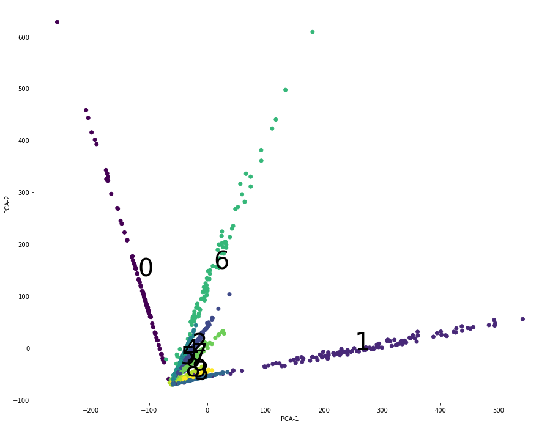

```python
# To label centers with label values, we need means of x and y values of every label group
label_means = []
for i in range(10):
    pm = np.where(y==i)
    label_means.append( (pca_op[pm,0].mean(), pca_op[pm,1].mean()) )


plt.figure(figsize=(15,12))
plt.scatter(x = pca_op[:,0], y = pca_op[:,1], c=y)
for i in range(10):
    plt.text(x = label_means[i][0], y = label_means[i][1], s = str(i), fontsize = 40)
plt.xlabel('PCA-1')
plt.ylabel('PCA-2')
plt.show()
```

### FIFTH HIDDEN LAYER

```python
# Get output of fifth hidden layer

first_hidden = inter_op['fp5']
print(first_hidden.shape)

# Using t-SNE
from sklearn.manifold import TSNE
from sklearn.preprocessing import StandardScaler
from sklearn.decomposition import PCA
import pandas as pd

# x = mnist_test.data[:1000].reshape(-1, 784).cpu().numpy()
# y = mnist_test.targets[:1000].cpu().numpy()

x = first_hidden.cpu().detach().numpy()
print(x.shape)
y = labels.cpu().numpy()

# TO obtain TSNE embedding from 784 dimensions to 2 dimensions
n_components = 2
tsne = TSNE(n_components)
tsne_op = tsne.fit_transform(x)

# scale data before pca - sensitive to scaling (covariance is dependent on scale of variables)
# x_scaled = StandardScaler().fit_transform(x)
# No need to scale now, as input data is already normalized
pca = PCA(n_components=2)
pca_op = pca.fit_transform(x)
```

```
torch.Size([1000, 1024])
(1000, 1024)
```

```
(1000, 2) (1000, 2)
10
```

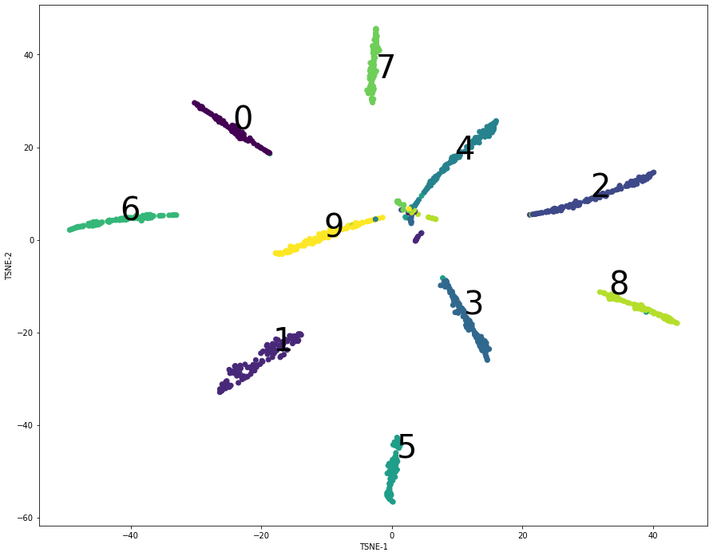

```python
print(pca_op.shape, tsne_op.shape)

# To label centers with label values, we need means of x and y values of every label group
label_means = []
for i in range(10):
    pm = np.where(y==i)
    label_means.append( (tsne_op[pm,0].mean(), tsne_op[pm,1].mean()) )

print(len(label_means))

plt.figure(figsize=(15,12))
plt.scatter(x = tsne_op[:,0], y = tsne_op[:,1], c=y)
for i in range(10):
    plt.text(x = label_means[i][0], y = label_means[i][1], s = str(i), fontsize = 40)
plt.xlabel('TSNE-1')
plt.ylabel('TSNE-2')
plt.show()
```

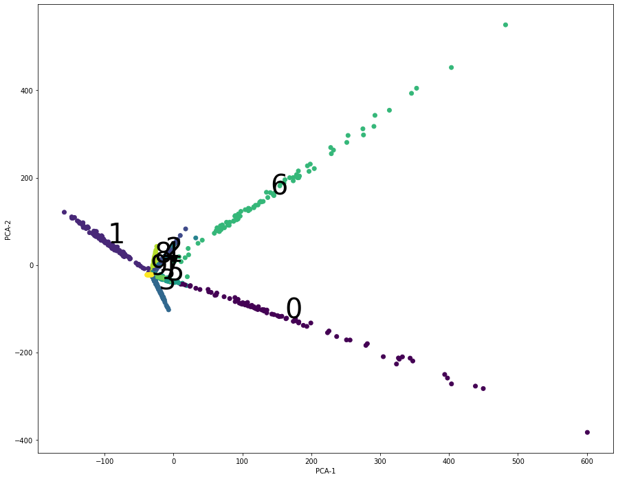

```python
# To label centers with label values, we need means of x and y values of every label group
label_means = []
for i in range(10):
    pm = np.where(y==i)
    label_means.append( (pca_op[pm,0].mean(), pca_op[pm,1].mean()) )


plt.figure(figsize=(15,12))
plt.scatter(x = pca_op[:,0], y = pca_op[:,1], c=y)
for i in range(10):
    plt.text(x = label_means[i][0], y = label_means[i][1], s = str(i), fontsize = 40)
plt.xlabel('PCA-1')
plt.ylabel('PCA-2')
plt.show()
```

#### Explanation of using hidden layer outputs instead of raw image values:

#### When we use hidden layer outputs, we see a much better cluster segmentation among the data points. And this cluster separation gets better with deeper hidden layer outputs. This is because hidden layers get inputs which are transformed in non-linear space and after it trains on that input, it has a much better understanding of data and for those data points which are very hard to classify on lower dimensional space are easier to classify if transformed to a higher dimensional space, which is what each nerual network layer does. Also, the neural networks understand and learn which features or neurons are important and which are not, and learns only the significant features that most contribute to learning correct labels. And in the fifth hidden layer output PCA graph, we see how the points of most affecting feature vectors (or principal components) are pointing in one direction. And the tSNE graph of the last hidden layer has the most clear separation in points and the clusters are very well organized and very easily distinguishable.

## Problem 2.1

```python
# Define a constant template and change activation functions and weight initializations
#Uniform initialization

def normal_weights(m):
    if isinstance(m, nn.Linear):
        torch.nn.init.normal_(m.weight, mean=0.0, std=0.01)
        m.bias.data.fill_(0.01)


def xavier_weights(m):
    if isinstance(m, nn.Linear):
        torch.nn.init.xavier_uniform_(m.weight)
        m.bias.data.fill_(0.01)

def he_weights(m):
    if isinstance(m, nn.Linear):
        torch.nn.init.kaiming_uniform_(m.weight, mode='fan_in')
#         print(m.weight)
        m.bias.data.fill_(0.01)



# A and B.
class NN_ab(nn.Module):

    def __init__(self):
        super(NN_ab, self).__init__() # any init calls before this should also call this init only
        self.fp_input = nn.Linear(28*28, 512)
        self.fp1 = nn.Linear(512, 512)
        self.fp2 = nn.Linear(512, 512)
        self.fp3 = nn.Linear(512, 512)
        self.fp4 = nn.Linear(512, 512)
        self.fp5 = nn.Linear(512, 512)
        self.fp_output = nn.Linear(512, 10)
        self.dropout = nn.Dropout(0.2) # Dropouts not needed for this question

    def forward(self, input):
        to_save_layerop = {}

        # flatten input already so that it is a row vector
        input = self.fp_input(input)
        input = torch.sigmoid(input)

        input = self.fp1(input)
        input = torch.sigmoid(input)

        input = self.fp2(input)
        input = torch.sigmoid(input)

        input = self.fp3(input)
        input = torch.sigmoid(input)

        input = self.fp4(input)
        input = torch.sigmoid(input)

        input = self.fp5(input)
        input = torch.sigmoid(input)

        input = self.fp_output(input)
        return input, to_save_layerop



# C, D, E.

class NN_cde(nn.Module):

    def __init__(self):
        super(NN_cde, self).__init__() # any init calls before this should also call this init only
        self.fp_input = nn.Linear(28*28, 512)
        self.fp1 = nn.Linear(512, 512)
        self.fp2 = nn.Linear(512, 512)
        self.fp3 = nn.Linear(512, 512)
        self.fp4 = nn.Linear(512, 512)
        self.fp5 = nn.Linear(512, 512)
        self.fp_output = nn.Linear(512, 10)
        self.dropout = nn.Dropout(0.2) # Dropouts not needed for this question

    def forward(self, input):
        to_save_layerop = {}

        # flatten input already so that it is a row vector
        input = self.fp_input(input)
        input = func.relu(input)

        input = self.fp1(input)
        input = func.relu(input)

        input = self.fp2(input)
        input = func.relu(input)

        input = self.fp3(input)
        input = func.relu(input)

        input = self.fp4(input)
        input = func.relu(input)

        input = self.fp5(input)
        input = func.relu(input)

        input = self.fp_output(input)
        return input, to_save_layerop






# Need to set optimizers and loss functions
def create_and_run_network(init_type, activation_type, optimizer_choice, lr):
    # A minor difference is that the implementation of CrossEntrypyLoss implicitly applies a softmax activation followed by a log transformation
    # but NLLLoss does not.
    if(torch.cuda.is_available()):
        device = torch.device('cuda')

    # Calling the NN class
    net = None
    loss_func = None
    optimizer = None
    loss = None
    MAX_PERFORMANCE_WEIGHTS = None


    if(activation_type == 'sigmoid'):
        net = NN_ab()
        net = net.to(device)
        if(init_type == 'normal'):
            net.apply(normal_weights)
        if(init_type == 'xavier'):
            net.apply(xavier_weights)
        if(init_type == 'he'):
            net.apply(he_weights)

    elif(activation_type == 'relu'):
        net = NN_cde()
        net = net.to(device)
        if(init_type == 'normal'):
            net.apply(normal_weights)
        if(init_type == 'xavier'):
            net.apply(xavier_weights)
        if(init_type == 'he'):
            net.apply(he_weights)

    loss_func = nn.CrossEntropyLoss()

    if(optimizer_choice == 'sgd'):
        optimizer = torch.optim.SGD(net.parameters(), lr = lr)
    elif(optimizer_choice == 'adam'):
        optimizer = torch.optim.Adam(net.parameters())

    train_loss_all = []
    valid_loss_all = []
    valid_performance = []

    max_performance = -99
    tolerance_level = 0
    performance = 0

    epochs = 150
    for epoch in range(1, epochs):
        train_loss = 0
        valid_loss = 0

        # Always have this line to ensure proper training
        net.train()

        for i, (data, labels) in enumerate(train_loader):
            data = data.reshape(-1, 784)

            # Push all variables to cuda
            if(torch.cuda.is_available()):
                data, labels =  data.to(device), labels.to(device)

            output, inter_op = net(data)
            loss = loss_func(output, labels)

            optimizer.zero_grad() # reset gradients
            loss.backward()
            optimizer.step()

            # Track loss
            train_loss += loss.item()

        # Now do validation and keep track of valid loss
        # Always have this line to ensure proper evaluation
        net.eval()

        actual_labels_all = []
        pred_labels_all = []
        # Now do validation and keep track of valid loss
        with torch.no_grad():
            for i, (data, labels) in enumerate(valid_loader):
                data = data.reshape(-1, 784)

                if(torch.cuda.is_available()):
                    data, labels = data.to(device), labels.to(device)

                # FP
                val_labels_pred_logits, inter_op = net.forward(data)

                v_loss = loss_func(val_labels_pred_logits, labels)
                valid_loss += v_loss.item()

                val_labels_pred_logits = func.softmax(val_labels_pred_logits, dim = 1)
                val_labels_pred_digits = val_labels_pred_logits.argmax(dim=1, keepdim=True)

                actual_labels_all.append(labels.cpu().numpy())
                pred_labels_all.append(val_labels_pred_digits.cpu().numpy())


        all_preds = np.concatenate(pred_labels_all, axis=0)
        all_targets = np.concatenate(actual_labels_all, axis=0)
        performance = accuracy_score( all_preds, all_targets)
        valid_performance.append(performance*100)

        if(epoch % 10 == 0):
            print(f'Epoch {epoch} \t\t Training loss: {train_loss/len(mnist_train)} \t\t Validation loss: {valid_loss/len(mnist_test)} \
            Validation Accuracy: {performance*100} %')

        train_loss_all.append(train_loss/len(mnist_train))
        valid_loss_all.append(valid_loss/len(mnist_test))

        if(performance*100 > max_performance):
            max_performance = performance*100
#             tolerance_level = 0
#             # Save Model
#             MAX_PERFORMANCE_WEIGHTS = net.state_dict()

#         else:
#             tolerance_level+=1
#             if(tolerance_level >= 10):
#                 early_stopping_activated = 1
#                 print('Early Stopping activated - no improvement in validation accuracy for the past 10 epochs. Using model stage before 10 epochs for further use.')


    print(' For parameters ', optimizer_choice, activation_type, init_type, ' Best Performance on Validation set(Same as Test data here) achived till now :', max_performance)
    return net, MAX_PERFORMANCE_WEIGHTS, valid_performance
```

```python
# Call all 10 networks and compare on graph
# With SGD
net = None
net_a_sgd, _, valid_performance_a_sgd = create_and_run_network(init_type = 'normal', activation_type = 'sigmoid', optimizer_choice = 'sgd', lr = 0.01)
```

```
Epoch 10 		 Training loss: 0.01800601718823115 		 Validation loss: 0.018191600251197815             Validation Accuracy: 10.280000000000001 %
Epoch 20 		 Training loss: 0.01800429989496867 		 Validation loss: 0.018195211696624757             Validation Accuracy: 11.35 %
Epoch 30 		 Training loss: 0.01800587046146393 		 Validation loss: 0.018197234392166136             Validation Accuracy: 11.35 %
Epoch 40 		 Training loss: 0.01800441240866979 		 Validation loss: 0.01819595685005188             Validation Accuracy: 11.35 %
Epoch 50 		 Training loss: 0.018005198113123577 		 Validation loss: 0.01818626756668091             Validation Accuracy: 11.35 %
Epoch 60 		 Training loss: 0.0180041312734286 		 Validation loss: 0.018182515025138856             Validation Accuracy: 11.35 %
Epoch 70 		 Training loss: 0.018000881040096284 		 Validation loss: 0.018218191719055175             Validation Accuracy: 9.82 %
Epoch 80 		 Training loss: 0.01800128400325775 		 Validation loss: 0.018199072194099428             Validation Accuracy: 10.100000000000001 %
Epoch 90 		 Training loss: 0.018003712395826977 		 Validation loss: 0.01819560687541962             Validation Accuracy: 11.35 %
Epoch 100 		 Training loss: 0.01800292488336563 		 Validation loss: 0.018182958030700684             Validation Accuracy: 11.35 %
Epoch 110 		 Training loss: 0.01800182792743047 		 Validation loss: 0.01819234251976013             Validation Accuracy: 9.8 %
Epoch 120 		 Training loss: 0.01800087106625239 		 Validation loss: 0.018187542986869813             Validation Accuracy: 11.35 %
Epoch 130 		 Training loss: 0.018002140041192372 		 Validation loss: 0.018203577733039857             Validation Accuracy: 9.58 %
Epoch 140 		 Training loss: 0.018001063394546508 		 Validation loss: 0.018183802485466003             Validation Accuracy: 11.35 %
 For parameters  sgd sigmoid normal  Best Performance on Validation set(Same as Test data here) achived till now : 11.35
```

```python
net = None
net_b_sgd, _, valid_performance_b_sgd = create_and_run_network(init_type = 'xavier', activation_type = 'sigmoid', optimizer_choice = 'sgd', lr = 0.01)
```

```
Epoch 10 		 Training loss: 0.01800905176003774 		 Validation loss: 0.018189984226226807             Validation Accuracy: 11.35 %
Epoch 20 		 Training loss: 0.018006928241252898 		 Validation loss: 0.018201026463508605             Validation Accuracy: 9.58 %
Epoch 30 		 Training loss: 0.018005162890752158 		 Validation loss: 0.018196094155311586             Validation Accuracy: 11.35 %
Epoch 40 		 Training loss: 0.01800331288178762 		 Validation loss: 0.018206400966644287             Validation Accuracy: 9.82 %
Epoch 50 		 Training loss: 0.018000947749614717 		 Validation loss: 0.018193609142303467             Validation Accuracy: 10.280000000000001 %
Epoch 60 		 Training loss: 0.017999964320659638 		 Validation loss: 0.018181689405441286             Validation Accuracy: 11.35 %
Epoch 70 		 Training loss: 0.017996762975056965 		 Validation loss: 0.018189228534698485             Validation Accuracy: 9.74 %
Epoch 80 		 Training loss: 0.0179932124376297 		 Validation loss: 0.01819188449382782             Validation Accuracy: 10.09 %
Epoch 90 		 Training loss: 0.017988743754227956 		 Validation loss: 0.018181454038619996             Validation Accuracy: 10.09 %
Epoch 100 		 Training loss: 0.017984260551134744 		 Validation loss: 0.018179779195785523             Validation Accuracy: 11.35 %
Epoch 110 		 Training loss: 0.017970929141839346 		 Validation loss: 0.018164574837684633             Validation Accuracy: 10.280000000000001 %
Epoch 120 		 Training loss: 0.01794278785387675 		 Validation loss: 0.01811952202320099             Validation Accuracy: 11.35 %
Epoch 130 		 Training loss: 0.017794945216178894 		 Validation loss: 0.017946347522735596             Validation Accuracy: 23.41 %
Epoch 140 		 Training loss: 0.013666365545988083 		 Validation loss: 0.013480677688121796             Validation Accuracy: 33.26 %
 For parameters  sgd sigmoid xavier  Best Performance on Validation set(Same as Test data here) achived till now : 43.85
```

```python
net = None
net_c_sgd, _, valid_performance_c_sgd = create_and_run_network(init_type = 'normal', activation_type = 'relu', optimizer_choice = 'sgd', lr = 0.01)
```

```
Epoch 10 		 Training loss: 0.0179876074274381 		 Validation loss: 0.018178223395347595             Validation Accuracy: 11.35 %
Epoch 20 		 Training loss: 0.01798752086162567 		 Validation loss: 0.01817815341949463             Validation Accuracy: 11.35 %
Epoch 30 		 Training loss: 0.01798736672004064 		 Validation loss: 0.018178042817115783             Validation Accuracy: 11.35 %
Epoch 40 		 Training loss: 0.017987236030896504 		 Validation loss: 0.01817786910533905             Validation Accuracy: 11.35 %
Epoch 50 		 Training loss: 0.01798710052172343 		 Validation loss: 0.018177657270431517             Validation Accuracy: 11.35 %
Epoch 60 		 Training loss: 0.017986785129706064 		 Validation loss: 0.018177372145652772             Validation Accuracy: 11.35 %
Epoch 70 		 Training loss: 0.017986296276251475 		 Validation loss: 0.01817677285671234             Validation Accuracy: 11.35 %
Epoch 80 		 Training loss: 0.017985135014851886 		 Validation loss: 0.018175547456741332             Validation Accuracy: 11.35 %
Epoch 90 		 Training loss: 0.01798000112771988 		 Validation loss: 0.018169601583480834             Validation Accuracy: 11.35 %
Epoch 100 		 Training loss: 0.014316456508636475 		 Validation loss: 0.013614696443080903             Validation Accuracy: 26.33 %
Epoch 110 		 Training loss: 0.0034656176654001077 		 Validation loss: 0.003272716227918863             Validation Accuracy: 90.01 %
Epoch 120 		 Training loss: 0.0007942565280633668 		 Validation loss: 0.0024215909517370164             Validation Accuracy: 93.58 %
Epoch 130 		 Training loss: 0.000269577638055974 		 Validation loss: 0.002992258827807382             Validation Accuracy: 93.8 %
Epoch 140 		 Training loss: 0.00012616622843197547 		 Validation loss: 0.003137052971695084             Validation Accuracy: 94.28999999999999 %
 For parameters  sgd relu normal  Best Performance on Validation set(Same as Test data here) achived till now : 94.92
```

```python
net = None
net_d_sgd, _, valid_performance_d_sgd = create_and_run_network(init_type = 'xavier', activation_type = 'relu', optimizer_choice = 'sgd', lr = 0.01)
```

```
Epoch 10 		 Training loss: 0.0005141111528966576 		 Validation loss: 0.0007269778451242018             Validation Accuracy: 97.28 %
Epoch 20 		 Training loss: 0.000145773348340299 		 Validation loss: 0.0006181744910103589             Validation Accuracy: 97.75 %
Epoch 30 		 Training loss: 4.0412919520167635e-05 		 Validation loss: 0.0006562054440935754             Validation Accuracy: 97.72 %
Epoch 40 		 Training loss: 1.4906520058381526e-05 		 Validation loss: 0.0006977055534391184             Validation Accuracy: 97.8 %
Epoch 50 		 Training loss: 7.834268607014867e-06 		 Validation loss: 0.0007392544315927808             Validation Accuracy: 97.83 %
Epoch 60 		 Training loss: 5.168998177396133e-06 		 Validation loss: 0.0007667114697460647             Validation Accuracy: 97.81 %
Epoch 70 		 Training loss: 3.7583458399846373e-06 		 Validation loss: 0.0007971349947743192             Validation Accuracy: 97.71 %
Epoch 80 		 Training loss: 2.9146206897470013e-06 		 Validation loss: 0.0008107998684640108             Validation Accuracy: 97.83 %
Epoch 90 		 Training loss: 2.363258547363027e-06 		 Validation loss: 0.0008321534755321125             Validation Accuracy: 97.78999999999999 %
Epoch 100 		 Training loss: 1.9673651927102278e-06 		 Validation loss: 0.0008462894289853409             Validation Accuracy: 97.78999999999999 %
Epoch 110 		 Training loss: 1.6794946473964956e-06 		 Validation loss: 0.0008591757090171853             Validation Accuracy: 97.77 %
Epoch 120 		 Training loss: 1.457117107444598e-06 		 Validation loss: 0.000871548159453323             Validation Accuracy: 97.78999999999999 %
Epoch 130 		 Training loss: 1.2797683468609952e-06 		 Validation loss: 0.0008835086719292463             Validation Accuracy: 97.78 %
Epoch 140 		 Training loss: 1.1393027252173246e-06 		 Validation loss: 0.0008931577033735891             Validation Accuracy: 97.78999999999999 %
 For parameters  sgd relu xavier  Best Performance on Validation set(Same as Test data here) achived till now : 97.84
```

```python
net = None
net_e_sgd, _, valid_performance_e_sgd = create_and_run_network(init_type = 'he', activation_type = 'relu', optimizer_choice = 'sgd', lr = 0.01)
```

```
Epoch 10 		 Training loss: 0.00023173364065587522 		 Validation loss: 0.0007157080170407425             Validation Accuracy: 97.33000000000001 %
Epoch 20 		 Training loss: 3.5809316243588305e-05 		 Validation loss: 0.0007253402454167372             Validation Accuracy: 97.46000000000001 %
Epoch 30 		 Training loss: 1.3214401224589286e-05 		 Validation loss: 0.0007599706677941867             Validation Accuracy: 97.55 %
Epoch 40 		 Training loss: 7.600670511237695e-06 		 Validation loss: 0.0008026563721083221             Validation Accuracy: 97.53 %
Epoch 50 		 Training loss: 5.179331797868751e-06 		 Validation loss: 0.0008287210247563052             Validation Accuracy: 97.54 %
Epoch 60 		 Training loss: 3.84945066277093e-06 		 Validation loss: 0.000849726398913117             Validation Accuracy: 97.54 %
Epoch 70 		 Training loss: 3.0214831088111775e-06 		 Validation loss: 0.0008684776476506613             Validation Accuracy: 97.56 %
Epoch 80 		 Training loss: 2.471479713616039e-06 		 Validation loss: 0.000883488024266353             Validation Accuracy: 97.59 %
Epoch 90 		 Training loss: 2.0725618211145046e-06 		 Validation loss: 0.0008969569549445623             Validation Accuracy: 97.58 %
Epoch 100 		 Training loss: 1.7737060273854392e-06 		 Validation loss: 0.0009070206074207818             Validation Accuracy: 97.61999999999999 %
Epoch 110 		 Training loss: 1.5465126851267997e-06 		 Validation loss: 0.0009171762573583919             Validation Accuracy: 97.6 %
Epoch 120 		 Training loss: 1.3671759827047936e-06 		 Validation loss: 0.0009284224373493089             Validation Accuracy: 97.59 %
Epoch 130 		 Training loss: 1.2213532120464758e-06 		 Validation loss: 0.0009370203866894372             Validation Accuracy: 97.58 %
Epoch 140 		 Training loss: 1.0996964253839298e-06 		 Validation loss: 0.0009461581216481363             Validation Accuracy: 97.6 %
 For parameters  sgd relu he  Best Performance on Validation set(Same as Test data here) achived till now : 97.63
```

```python
# With Adam (does not use the lr value that is passed in the function)
net = None
net_a_adam, _, valid_performance_a_adam = create_and_run_network(init_type = 'normal', activation_type = 'sigmoid', optimizer_choice = 'adam', lr = 0.01)
```

```
Epoch 10 		 Training loss: 0.00063612290606834 		 Validation loss: 0.001185324176447466             Validation Accuracy: 95.97 %
Epoch 20 		 Training loss: 0.00028128865526717465 		 Validation loss: 0.0009065997533500194             Validation Accuracy: 97.27 %
Epoch 30 		 Training loss: 0.0001514555204693655 		 Validation loss: 0.0008896312523575034             Validation Accuracy: 97.59 %
Epoch 40 		 Training loss: 9.932311702965914e-05 		 Validation loss: 0.000884923779865494             Validation Accuracy: 97.68 %
Epoch 50 		 Training loss: 8.042046184903787e-05 		 Validation loss: 0.000965740033617476             Validation Accuracy: 97.85000000000001 %
Epoch 60 		 Training loss: 7.746699493679141e-05 		 Validation loss: 0.0009527523194628884             Validation Accuracy: 97.94 %
Epoch 70 		 Training loss: 7.733994974805682e-05 		 Validation loss: 0.0010514007882164152             Validation Accuracy: 97.78 %
Epoch 80 		 Training loss: 4.4316030887057425e-05 		 Validation loss: 0.00098834660618013             Validation Accuracy: 97.96000000000001 %
Epoch 90 		 Training loss: 5.147832352607414e-05 		 Validation loss: 0.001130520695935411             Validation Accuracy: 97.64 %
Epoch 100 		 Training loss: 5.3758339097718515e-05 		 Validation loss: 0.0010817512731882745             Validation Accuracy: 98.06 %
Epoch 110 		 Training loss: 4.6268804304781954e-05 		 Validation loss: 0.0010342122123220179             Validation Accuracy: 97.89 %
Epoch 120 		 Training loss: 3.5450094238755506e-05 		 Validation loss: 0.0012277933590034082             Validation Accuracy: 97.88 %
Epoch 130 		 Training loss: 6.571211817639171e-05 		 Validation loss: 0.0010942834194233             Validation Accuracy: 97.92999999999999 %
Epoch 140 		 Training loss: 5.557960343127585e-05 		 Validation loss: 0.0012059283460872394             Validation Accuracy: 97.98 %
 For parameters  adam sigmoid normal  Best Performance on Validation set(Same as Test data here) achived till now : 98.22999999999999
```

```python
net = None
net_b_adam, _, valid_performance_b_adam = create_and_run_network(init_type = 'xavier', activation_type = 'sigmoid', optimizer_choice = 'adam', lr = 0.01)
```

```
Epoch 10 		 Training loss: 0.0002936038301015894 		 Validation loss: 0.0008141798999160529             Validation Accuracy: 97.54 %
Epoch 20 		 Training loss: 0.00014634647796240945 		 Validation loss: 0.0009194309173035435             Validation Accuracy: 97.58 %
Epoch 30 		 Training loss: 8.940991201125144e-05 		 Validation loss: 0.0009044247626123251             Validation Accuracy: 97.58 %
Epoch 40 		 Training loss: 8.200266805179126e-05 		 Validation loss: 0.0009145890942803817             Validation Accuracy: 97.86 %
Epoch 50 		 Training loss: 7.804705286058985e-05 		 Validation loss: 0.000904741425953398             Validation Accuracy: 98.05 %
Epoch 60 		 Training loss: 5.450956730807472e-05 		 Validation loss: 0.0009015531399774772             Validation Accuracy: 97.95 %
Epoch 70 		 Training loss: 6.897208460971645e-05 		 Validation loss: 0.0007145414305283339             Validation Accuracy: 98.19 %
Epoch 80 		 Training loss: 4.929989462762023e-05 		 Validation loss: 0.0011885774490900075             Validation Accuracy: 97.74000000000001 %
Epoch 90 		 Training loss: 3.8526576929840907e-05 		 Validation loss: 0.001131617943128913             Validation Accuracy: 97.98 %
Epoch 100 		 Training loss: 2.278749236575095e-05 		 Validation loss: 0.0011869192438953178             Validation Accuracy: 97.86 %
Epoch 110 		 Training loss: 5.284953726738119e-05 		 Validation loss: 0.0011221765428908838             Validation Accuracy: 97.83 %
Epoch 120 		 Training loss: 4.294989557917385e-05 		 Validation loss: 0.000842547262685548             Validation Accuracy: 98.22999999999999 %
Epoch 130 		 Training loss: 1.9898830874270364e-05 		 Validation loss: 0.0012280752141758057             Validation Accuracy: 98.06 %
Epoch 140 		 Training loss: 3.8848360436380366e-05 		 Validation loss: 0.000814189703259035             Validation Accuracy: 98.32 %
 For parameters  adam sigmoid xavier  Best Performance on Validation set(Same as Test data here) achived till now : 98.38
```

```python
net = None
net_c_adam, _, valid_performance_c_adam = create_and_run_network(init_type = 'normal', activation_type = 'relu', optimizer_choice = 'adam', lr = 0.01)
```

```
Epoch 10 		 Training loss: 0.0003144452685082797 		 Validation loss: 0.0007037729772644525             Validation Accuracy: 97.76 %
Epoch 20 		 Training loss: 0.00014947220410055402 		 Validation loss: 0.0008472511145331737             Validation Accuracy: 97.88 %
Epoch 30 		 Training loss: 0.00012705969647916693 		 Validation loss: 0.0009268755124440247             Validation Accuracy: 98.03 %
Epoch 40 		 Training loss: 6.334237333337947e-05 		 Validation loss: 0.0010215095707785593             Validation Accuracy: 98.02 %
Epoch 50 		 Training loss: 5.741484434255284e-05 		 Validation loss: 0.0013089818374169998             Validation Accuracy: 98.3 %
Epoch 60 		 Training loss: 3.0153158715448198e-05 		 Validation loss: 0.0016231741341487158             Validation Accuracy: 97.92999999999999 %
Epoch 70 		 Training loss: 4.66399748594957e-05 		 Validation loss: 0.0011169500285981534             Validation Accuracy: 98.03 %
Epoch 80 		 Training loss: 1.1940290977563055e-05 		 Validation loss: 0.0012946961389306022             Validation Accuracy: 98.22 %
Epoch 90 		 Training loss: 5.829230321286805e-05 		 Validation loss: 0.0014740575413152456             Validation Accuracy: 98.22999999999999 %
Epoch 100 		 Training loss: 4.7951339236357174e-05 		 Validation loss: 0.0011013440678728913             Validation Accuracy: 98.25 %
Epoch 110 		 Training loss: 1.3483461292520064e-05 		 Validation loss: 0.002307912725035497             Validation Accuracy: 98.27 %
Epoch 120 		 Training loss: 0.000141594994279482 		 Validation loss: 0.0011855914614909814             Validation Accuracy: 98.16 %
Epoch 130 		 Training loss: 6.664912472948796e-09 		 Validation loss: 0.0020328519877453135             Validation Accuracy: 98.41 %
Epoch 140 		 Training loss: 2.8438595698991134e-10 		 Validation loss: 0.00249512407057445             Validation Accuracy: 98.41 %
 For parameters  adam relu normal  Best Performance on Validation set(Same as Test data here) achived till now : 98.53
```

```python
net = None
net_d_adam, _, valid_performance_d_adam = create_and_run_network(init_type = 'xavier', activation_type = 'relu', optimizer_choice = 'adam', lr = 0.01)
```

```
Epoch 10 		 Training loss: 0.0002646774364640199 		 Validation loss: 0.0008899677009385413             Validation Accuracy: 97.83 %
Epoch 20 		 Training loss: 0.00015462300825953813 		 Validation loss: 0.0010768493266846485             Validation Accuracy: 98.0 %
Epoch 30 		 Training loss: 0.00012330636836045155 		 Validation loss: 0.0012409507576629918             Validation Accuracy: 98.15 %
Epoch 40 		 Training loss: 8.656931055116435e-05 		 Validation loss: 0.0011101067119434476             Validation Accuracy: 98.31 %
Epoch 50 		 Training loss: 9.940801881501405e-05 		 Validation loss: 0.00108185115313699             Validation Accuracy: 98.36 %
Epoch 60 		 Training loss: 9.209187938459682e-05 		 Validation loss: 0.0012173717587920343             Validation Accuracy: 98.15 %
Epoch 70 		 Training loss: 8.196873323049611e-05 		 Validation loss: 0.0010817637094599206             Validation Accuracy: 98.37 %
Epoch 80 		 Training loss: 0.0001008100930213402 		 Validation loss: 0.0011588895230270826             Validation Accuracy: 98.3 %
Epoch 90 		 Training loss: 3.6715678365892285e-05 		 Validation loss: 0.000924614861837702             Validation Accuracy: 98.47 %
Epoch 100 		 Training loss: 0.00011525996914206924 		 Validation loss: 0.0014605588868841213             Validation Accuracy: 98.5 %
Epoch 110 		 Training loss: 6.546005334151812e-05 		 Validation loss: 0.0019184805843173764             Validation Accuracy: 98.07000000000001 %
Epoch 120 		 Training loss: 3.832104550718895e-06 		 Validation loss: 0.0013952292116215616             Validation Accuracy: 98.63 %
Epoch 130 		 Training loss: 9.170230972842669e-05 		 Validation loss: 0.0013176347134948858             Validation Accuracy: 98.29 %
Epoch 140 		 Training loss: 0.00015348963041982724 		 Validation loss: 0.0011181992894787715             Validation Accuracy: 98.54 %
 For parameters  adam relu xavier  Best Performance on Validation set(Same as Test data here) achived till now : 98.71
```

```python
net = None
net_e_adam, _, valid_performance_e_adam = create_and_run_network(init_type = 'he', activation_type = 'relu', optimizer_choice = 'adam', lr = 0.01)
```

```
Epoch 10 		 Training loss: 0.0002436324713982079 		 Validation loss: 0.001011759439733578             Validation Accuracy: 97.11999999999999 %
Epoch 20 		 Training loss: 0.0001694134356037921 		 Validation loss: 0.0009694089551110665             Validation Accuracy: 97.85000000000001 %
Epoch 30 		 Training loss: 0.0001390599546938309 		 Validation loss: 0.0013188324260398985             Validation Accuracy: 97.54 %
Epoch 40 		 Training loss: 8.034515367658627e-05 		 Validation loss: 0.0011501824909774016             Validation Accuracy: 98.15 %
Epoch 50 		 Training loss: 0.00012035389412835826 		 Validation loss: 0.0011012499310387453             Validation Accuracy: 97.91 %
Epoch 60 		 Training loss: 9.750134417511163e-05 		 Validation loss: 0.0015147341688618128             Validation Accuracy: 97.94 %
Epoch 70 		 Training loss: 6.494351170476755e-05 		 Validation loss: 0.0012627318723623404             Validation Accuracy: 98.08 %
Epoch 80 		 Training loss: 8.438215850483744e-05 		 Validation loss: 0.0009058383438547452             Validation Accuracy: 98.47 %
Epoch 90 		 Training loss: 0.00012555310892319748 		 Validation loss: 0.0013186292781911103             Validation Accuracy: 98.06 %
Epoch 100 		 Training loss: 4.7017196990611866e-05 		 Validation loss: 0.0020113162675316027             Validation Accuracy: 98.31 %
Epoch 110 		 Training loss: 0.0001261350464784364 		 Validation loss: 0.0018934138329536382             Validation Accuracy: 96.67 %
Epoch 120 		 Training loss: 0.0001509981534145087 		 Validation loss: 0.0015703312559711019             Validation Accuracy: 98.44000000000001 %
Epoch 130 		 Training loss: 0.00016164000057286194 		 Validation loss: 0.0017065157405852982             Validation Accuracy: 97.7 %
Epoch 140 		 Training loss: 7.309441112221767e-05 		 Validation loss: 0.0014639280477582943             Validation Accuracy: 98.02 %
 For parameters  adam relu he  Best Performance on Validation set(Same as Test data here) achived till now : 98.56
```

```python
epochs_range = [i for i in range(len(valid_performance_a_sgd))]
epochs_range[:10]
```

```
[0, 1, 2, 3, 4, 5, 6, 7, 8, 9]
```

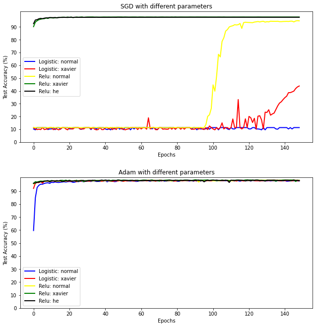

```python
# Plot graphs
import matplotlib.pyplot as plt
import numpy as np

fig, axes = plt.subplots(2, 1, figsize = (10,10) )
fig.tight_layout(pad=5.0)

for i in range(2):
    if(i == 0):
        ax = axes[i]
        ax.plot(epochs_range, valid_performance_a_sgd, label = 'Logistic: normal', color="blue", linewidth=2 )
        ax.plot(epochs_range, valid_performance_b_sgd, label = 'Logistic: xavier', color="red", linewidth=2 )
        ax.plot(epochs_range, valid_performance_c_sgd, label = 'Relu: normal', color="yellow", linewidth=2 )
        ax.plot(epochs_range, valid_performance_d_sgd, label = 'Relu: xavier', color="green", linewidth=2 )
        ax.plot(epochs_range, valid_performance_e_sgd, label = 'Relu: he', color="black", linewidth=2 )
        ax.set_xlabel('Epochs')
        ax.set_ylabel('Test Accuracy (%)')
        ax.legend()
        ax.set_yticks(np.arange(0, 100, 10))
        ax.set_title('SGD with different parameters')

    if(i == 1):
        ax = axes[i]
        ax.plot(epochs_range, valid_performance_a_adam, label = 'Logistic: normal', color="blue", linewidth=2  )
        ax.plot(epochs_range, valid_performance_b_adam, label = 'Logistic: xavier', color="red", linewidth=2  )
        ax.plot(epochs_range, valid_performance_c_adam, label = 'Relu: normal', color="yellow", linewidth=2  )
        ax.plot(epochs_range, valid_performance_d_adam, label = 'Relu: xavier', color="green", linewidth=2  )
        ax.plot(epochs_range, valid_performance_e_adam, label = 'Relu: he', color="black", linewidth=2  )
        ax.set_xlabel('Epochs')
        ax.set_ylabel('Test Accuracy (%)')
        ax.legend()
        ax.set_yticks(np.arange(0, 100, 10))
        ax.set_title('Adam with different parameters')
```

### We can look more closely at the Adam graph:

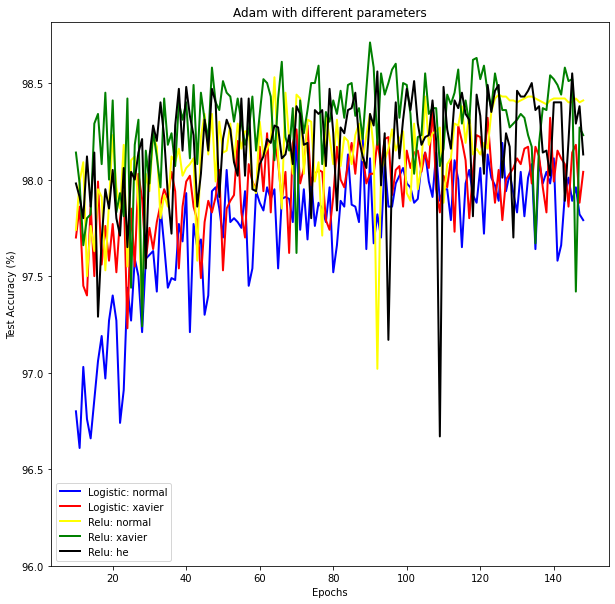

```python
plt.figure(figsize = (10,10))
plt.plot(epochs_range[10:], valid_performance_a_adam[10:], label = 'Logistic: normal', color="blue", linewidth=2  )
plt.plot(epochs_range[10:], valid_performance_b_adam[10:], label = 'Logistic: xavier', color="red", linewidth=2  )
plt.plot(epochs_range[10:], valid_performance_c_adam[10:], label = 'Relu: normal', color="yellow", linewidth=2  )
plt.plot(epochs_range[10:], valid_performance_d_adam[10:], label = 'Relu: xavier', color="green", linewidth=2  )
plt.plot(epochs_range[10:], valid_performance_e_adam[10:], label = 'Relu: he', color="black", linewidth=2  )
plt.xlabel('Epochs')
plt.ylabel('Test Accuracy (%)')
plt.legend()
plt.yticks(np.arange(96, 99, 0.5))
plt.title('Adam with different parameters')
```

### Problem 3

```python
### Define a constant template and change activation functions and weight initializations
#Uniform initialization

def normal_weights(m):
    if isinstance(m, nn.Linear):
        torch.nn.init.normal_(m.weight, mean=0.0, std=0.01)
        m.bias.data.fill_(0.01)


def xavier_weights(m):
    if isinstance(m, nn.Linear):
        torch.nn.init.xavier_uniform_(m.weight)
        m.bias.data.fill_(0.01)

def he_weights(m):
    if isinstance(m, nn.Linear):
        torch.nn.init.kaiming_uniform_(m.weight, mode='fan_in')
#         print(m.weight)
        m.bias.data.fill_(0.01)



# A and B.
class NN_3a(nn.Module):

    def __init__(self):
        super(NN_3a, self).__init__() # any init calls before this should also call this init only
        self.fp_input = nn.Linear(28*28, 1024)
        self.fp1 = nn.Linear(1024, 1024)
        self.fp2 = nn.Linear(1024, 1024)
        self.fp3 = nn.Linear(1024, 1024)
        self.fp4 = nn.Linear(1024, 1024)
        self.fp5 = nn.Linear(1024, 1024)
        self.fp_output = nn.Linear(1024, 10)

    def forward(self, input):
        to_save_layerop = {}

        # flatten input already so that it is a row vector
        input = self.fp_input(input)
        input = torch.sigmoid(input)

        input = self.fp1(input)
        input = torch.sigmoid(input)

        input = self.fp2(input)
        input = torch.sigmoid(input)

        input = self.fp3(input)
        input = torch.sigmoid(input)

        input = self.fp4(input)
        input = torch.sigmoid(input)

        input = self.fp5(input)
        input = torch.sigmoid(input)

        input = self.fp_output(input)
        return input, to_save_layerop




class NN_3b(nn.Module):

    def __init__(self):
        super(NN_3b, self).__init__() # any init calls before this should also call this init only
        self.fp_input = nn.Linear(28*28, 1024)
        self.fp1 = nn.Linear(1024, 1024)
        self.fp2 = nn.Linear(1024, 1024)
        self.fp3 = nn.Linear(1024, 1024)
        self.fp4 = nn.Linear(1024, 1024)
        self.fp5 = nn.Linear(1024, 1024)
        self.fp_output = nn.Linear(1024, 10)
        self.dropout1 = nn.Dropout(0.2)
        self.dropout2 = nn.Dropout(0.5)

    def forward(self, input):
        to_save_layerop = {}

        # flatten input already so that it is a row vector
        input = self.fp_input(input)
        input = func.sigmoid(input)
        input = self.dropout1(input)

        input = self.fp1(input)
        input = func.sigmoid(input)
        input = self.dropout2(input)

        input = self.fp2(input)
        input = func.sigmoid(input)
        input = self.dropout2(input)

        input = self.fp3(input)
        input = func.sigmoid(input)
        input = self.dropout2(input)

        input = self.fp4(input)
        input = func.sigmoid(input)
        input = self.dropout2(input)

        input = self.fp5(input)
        input = func.sigmoid(input)
        input = self.dropout2(input)

        input = self.fp_output(input)
        return input, to_save_layerop


# C, D

class NN_3c(nn.Module):

    def __init__(self):
        super(NN_3c, self).__init__() # any init calls before this should also call this init only
        self.fp_input = nn.Linear(28*28, 1024)
        self.fp1 = nn.Linear(1024, 1024)
        self.fp2 = nn.Linear(1024, 1024)
        self.fp3 = nn.Linear(1024, 1024)
        self.fp4 = nn.Linear(1024, 1024)
        self.fp5 = nn.Linear(1024, 1024)
        self.fp_output = nn.Linear(1024, 10)

    def forward(self, input):
        to_save_layerop = {}

        # flatten input already so that it is a row vector
        input = self.fp_input(input)
        input = func.relu(input)

        input = self.fp1(input)
        input = func.relu(input)

        input = self.fp2(input)
        input = func.relu(input)

        input = self.fp3(input)
        input = func.relu(input)

        input = self.fp4(input)
        input = func.relu(input)

        input = self.fp5(input)
        input = func.relu(input)

        input = self.fp_output(input)
        return input, to_save_layerop


class NN_3d(nn.Module):

    def __init__(self):
        super(NN_3d, self).__init__() # any init calls before this should also call this init only
        self.fp_input = nn.Linear(28*28, 1024)
        self.fp1 = nn.Linear(1024, 1024)
        self.fp2 = nn.Linear(1024, 1024)
        self.fp3 = nn.Linear(1024, 1024)
        self.fp4 = nn.Linear(1024, 1024)
        self.fp5 = nn.Linear(1024, 1024)
        self.fp_output = nn.Linear(1024, 10)
        self.dropout1 = nn.Dropout(0.2)
        self.dropout2 = nn.Dropout(0.5)

    def forward(self, input):
        to_save_layerop = {}

        # flatten input already so that it is a row vector
        input = self.fp_input(input)
        input = func.relu(input)
        input = self.dropout1(input)

        input = self.fp1(input)
        input = func.relu(input)
        input = self.dropout2(input)

        input = self.fp2(input)
        input = func.relu(input)
        input = self.dropout2(input)

        input = self.fp3(input)
        input = func.relu(input)
        input = self.dropout2(input)

        input = self.fp4(input)
        input = func.relu(input)
        input = self.dropout2(input)

        input = self.fp5(input)
        input = func.relu(input)
        input = self.dropout2(input)

        input = self.fp_output(input)
        return input, to_save_layerop




# Need to set optimizers and loss functions
def create_and_run_network(init_type, activation_type, optimizer_choice, lr, dropout):
    # A minor difference is that the implementation of CrossEntrypyLoss implicitly applies a softmax activation followed by a log transformation
    # but NLLLoss does not.
    if(torch.cuda.is_available()):
        device = torch.device('cuda')

    # Calling the NN class
    net = None
    loss_func = None
    optimizer = None
    loss = None
    MAX_PERFORMANCE_WEIGHTS = None


    if(activation_type == 'sigmoid' and dropout == 'no'):
        net = NN_3a()
        net = net.to(device)


    elif(activation_type == 'sigmoid' and dropout == 'yes'):
        net = NN_3b()
        net = net.to(device)

    elif(activation_type == 'relu' and dropout == 'no'):
        net = NN_3c()
        net = net.to(device)

    elif(activation_type == 'relu' and dropout == 'yes'):
        net = NN_3d()
        net = net.to(device)

    if(init_type == 'normal'):
        net.apply(normal_weights)
    if(init_type == 'xavier'):
        net.apply(xavier_weights)
    if(init_type == 'he'):
        net.apply(he_weights)

    loss_func = nn.CrossEntropyLoss()

    if(optimizer_choice == 'sgd'):
        optimizer = torch.optim.SGD(net.parameters(), lr = lr)
    elif(optimizer_choice == 'adam'):
        optimizer = torch.optim.Adam(net.parameters())

    train_loss_all = []
    valid_loss_all = []
    valid_performance = []

    max_performance = -99
    tolerance_level = 0
    performance = 0

    epochs = 150
    for epoch in range(1, epochs):
        train_loss = 0
        valid_loss = 0

        # Always have this line to ensure proper training
        net.train()

        for i, (data, labels) in enumerate(train_loader):
            data = data.reshape(-1, 784)

            # Push all variables to cuda
            if(torch.cuda.is_available()):
                data, labels =  data.to(device), labels.to(device)

            output, inter_op = net(data)
            loss = loss_func(output, labels)

            optimizer.zero_grad() # reset gradients
            loss.backward()
            optimizer.step()

            # Track loss
            train_loss += loss.item()

        # Now do validation and keep track of valid loss
        # Always have this line to ensure proper evaluation
        net.eval()

        actual_labels_all = []
        pred_labels_all = []
        # Now do validation and keep track of valid loss
        with torch.no_grad():
            for i, (data, labels) in enumerate(valid_loader):
                data = data.reshape(-1, 784)

                if(torch.cuda.is_available()):
                    data, labels = data.to(device), labels.to(device)

                # FP
                val_labels_pred_logits, inter_op = net.forward(data)

                v_loss = loss_func(val_labels_pred_logits, labels)
                valid_loss += v_loss.item()

                val_labels_pred_logits = func.softmax(val_labels_pred_logits, dim = 1)
                val_labels_pred_digits = val_labels_pred_logits.argmax(dim=1, keepdim=True)

                actual_labels_all.append(labels.cpu().numpy())
                pred_labels_all.append(val_labels_pred_digits.cpu().numpy())


        all_preds = np.concatenate(pred_labels_all, axis=0)
        all_targets = np.concatenate(actual_labels_all, axis=0)
        performance = accuracy_score( all_preds, all_targets)
        valid_performance.append(performance*100)

        if(epoch % 10 == 0):
            print(f'Epoch {epoch} \t\t Training loss: {train_loss/len(mnist_train)} \t\t Validation loss: {valid_loss/len(mnist_test)} \
            Validation Accuracy: {performance*100} %')

        train_loss_all.append(train_loss)
        valid_loss_all.append(valid_loss)

        if(performance*100 > max_performance):
            max_performance = performance*100

    print(' For parameters ', optimizer_choice, activation_type, init_type, ' Best Performance on Validation set(Same as Test data here) achived till now :', max_performance)
    return net, MAX_PERFORMANCE_WEIGHTS, valid_performance, train_loss_all, valid_loss_all
```

### Scale data before running - improves performance and also keeps loss values between 0 to 1...AND MOST IMPORTANTLY IT RUNS FASTER

```python
# Sigmoid without dropout

mnist_train=torchvision.datasets.MNIST('mnist',
                train=True,
                download=True,
                transform=torchvision.transforms.Compose([
                torchvision.transforms.ToTensor(),
                torchvision.transforms.Normalize((0.1307,), (0.3081,)),
                torchvision.transforms.Grayscale()
                ]))

mnist_test=torchvision.datasets.MNIST('mnist',
                train=False,
                download=True,
                transform=torchvision.transforms.Compose([
                torchvision.transforms.ToTensor(),
                torchvision.transforms.Normalize((0.1307,), (0.3081,)),
                torchvision.transforms.Grayscale()
                ]))


# Scale and then do all process
from sklearn.preprocessing import MinMaxScaler
from torch.utils.data import TensorDataset
scaler = MinMaxScaler()

scaled_train = []
for i in mnist_train.data:
    scaled_train.append(scaler.fit_transform(i))

scaled_test = []
for i in mnist_test.data:
    scaled_test.append(scaler.fit_transform(i))


tensor_x = torch.Tensor(scaled_train) # transform to torch tensor
tensor_y = torch.Tensor(mnist_train.targets)
train_dataset = TensorDataset(tensor_x,tensor_y) # create your datset

tensor_x = torch.Tensor(scaled_test) # transform to torch tensor
tensor_y = torch.Tensor(mnist_test.targets)
test_dataset = TensorDataset(tensor_x,tensor_y) # create your datset
```

```python
# Our MNIST is already in tensorDataset format
train_loader = torch.utils.data.DataLoader(dataset=train_dataset,
                                             batch_size=batch_size_train,
                                             shuffle=True)

# For all other problems, do valid loader without batch processing
valid_loader = torch.utils.data.DataLoader(dataset=test_dataset,
                                             batch_size=len(test_dataset),
                                             shuffle=False)
```

```python
# Sigmoid without dropout
net = None
net_a_sigmoid, _, valid_performance_a_sigmoid, train_loss_all_a_sigmoid, test_loss_all_a_sigmoid = create_and_run_network(init_type = 'xavier', activation_type = 'sigmoid', optimizer_choice = 'adam', lr = 0.01, dropout='no')
```

```
Epoch 10 		 Training loss: 0.0003104484283462322 		 Validation loss: 1.0356901586055755e-05             Validation Accuracy: 97.43 %
Epoch 20 		 Training loss: 0.00011711032602470368 		 Validation loss: 9.336710721254349e-06             Validation Accuracy: 98.21 %
Epoch 30 		 Training loss: 7.374961043351504e-05 		 Validation loss: 1.0425467789173126e-05             Validation Accuracy: 98.22999999999999 %
Epoch 40 		 Training loss: 3.993156070000623e-05 		 Validation loss: 1.2088121473789215e-05             Validation Accuracy: 98.15 %
Epoch 50 		 Training loss: 5.3127056892966115e-05 		 Validation loss: 1.2352601438760758e-05             Validation Accuracy: 98.08 %
Epoch 60 		 Training loss: 1.5180400689951056e-05 		 Validation loss: 1.31672203540802e-05             Validation Accuracy: 98.29 %
Epoch 70 		 Training loss: 3.1349516737873276e-05 		 Validation loss: 1.179167628288269e-05             Validation Accuracy: 98.1 %
Epoch 80 		 Training loss: 3.4365435762689835e-05 		 Validation loss: 1.3505466282367706e-05             Validation Accuracy: 98.1 %
Epoch 90 		 Training loss: 1.2458332235049359e-05 		 Validation loss: 1.445222645998001e-05             Validation Accuracy: 98.49 %
Epoch 100 		 Training loss: 9.408982189919849e-07 		 Validation loss: 1.4266629517078399e-05             Validation Accuracy: 98.57000000000001 %
Epoch 110 		 Training loss: 1.2112693344488434e-05 		 Validation loss: 1.7433960735797884e-05             Validation Accuracy: 98.08 %
Epoch 120 		 Training loss: 1.6613745448050092e-08 		 Validation loss: 1.657022535800934e-05             Validation Accuracy: 98.53 %
Epoch 130 		 Training loss: 9.111823054269719e-10 		 Validation loss: 1.9110335409641266e-05             Validation Accuracy: 98.54 %
Epoch 140 		 Training loss: 1.195293705680278e-10 		 Validation loss: 2.090197801589966e-05             Validation Accuracy: 98.53 %
 For parameters  adam sigmoid xavier  Best Performance on Validation set(Same as Test data here) achived till now : 98.57000000000001
```

```python
# Sigmoid with dropout
net = None
net_b_sigmoid, _, valid_performance_b_sigmoid, train_loss_all_b_sigmoid, test_loss_all_b_sigmoid = create_and_run_network(init_type = 'xavier', activation_type = 'sigmoid', optimizer_choice = 'adam', lr = 0.01, dropout='yes')
```

```
Epoch 10 		 Training loss: 0.0005466081014834345 		 Validation loss: 1.0916662961244584e-05             Validation Accuracy: 97.55 %
```

```
Epoch 20 		 Training loss: 0.00023265027099114377 		 Validation loss: 8.743319660425186e-06             Validation Accuracy: 98.25 %
```

```
Epoch 30 		 Training loss: 0.0001302931212693996 		 Validation loss: 9.70148742198944e-06             Validation Accuracy: 98.28 %
```

```
Epoch 40 		 Training loss: 0.00010203718712703751 		 Validation loss: 1.1028687655925751e-05             Validation Accuracy: 98.37 %
```

```
Epoch 50 		 Training loss: 8.759825374545471e-05 		 Validation loss: 1.1348439007997514e-05             Validation Accuracy: 98.32 %
```

```
Epoch 60 		 Training loss: 7.233642275614329e-05 		 Validation loss: 1.309439092874527e-05             Validation Accuracy: 98.32 %
```

```
Epoch 70 		 Training loss: 8.049408647454281e-05 		 Validation loss: 1.3730435073375702e-05             Validation Accuracy: 98.35000000000001 %
```

```
Epoch 80 		 Training loss: 5.073757472428042e-05 		 Validation loss: 1.3890533149242401e-05             Validation Accuracy: 98.63 %
```

```
Epoch 90 		 Training loss: 5.6099441319717396e-05 		 Validation loss: 1.4745131134986877e-05             Validation Accuracy: 98.52 %
```

```
Epoch 100 		 Training loss: 5.262403699981064e-05 		 Validation loss: 1.5837401151657103e-05             Validation Accuracy: 98.47 %
```

```
Epoch 110 		 Training loss: 5.018750659505713e-05 		 Validation loss: 1.7264702916145326e-05             Validation Accuracy: 98.56 %
```

```
Epoch 120 		 Training loss: 3.675408619270494e-05 		 Validation loss: 1.577260494232178e-05             Validation Accuracy: 98.48 %
```

```
Epoch 130 		 Training loss: 3.929186783479774e-05 		 Validation loss: 1.5675999224185942e-05             Validation Accuracy: 98.65 %
```

```
Epoch 140 		 Training loss: 3.382854026095382e-05 		 Validation loss: 1.9394138455390932e-05             Validation Accuracy: 98.38 %
```

```
 For parameters  adam sigmoid xavier  Best Performance on Validation set(Same as Test data here) achived till now : 98.68
```

```python
# relu without dropout
net = None
net_c_relu, _, valid_performance_c_relu, train_loss_all_c_relu, test_loss_all_c_relu = create_and_run_network(init_type = 'he', activation_type = 'relu', optimizer_choice = 'adam', lr = 0.01, dropout='no')
```

```
Epoch 10 		 Training loss: 0.0002331920391116 		 Validation loss: 1.3364695012569427e-05             Validation Accuracy: 97.58 %
Epoch 20 		 Training loss: 0.00012110771292074484 		 Validation loss: 1.2216370552778243e-05             Validation Accuracy: 98.05 %
Epoch 30 		 Training loss: 0.00013004418188300684 		 Validation loss: 1.2485112249851227e-05             Validation Accuracy: 98.35000000000001 %
Epoch 40 		 Training loss: 6.656103904502533e-05 		 Validation loss: 1.9552652537822725e-05             Validation Accuracy: 98.44000000000001 %
Epoch 50 		 Training loss: 0.0001257596042972881 		 Validation loss: 2.0469482243061066e-05             Validation Accuracy: 98.39 %
Epoch 60 		 Training loss: 7.868008471849224e-05 		 Validation loss: 2.3799262940883636e-05             Validation Accuracy: 97.95 %
Epoch 70 		 Training loss: 3.501336742014615e-05 		 Validation loss: 2.2309596836566927e-05             Validation Accuracy: 98.34 %
Epoch 80 		 Training loss: 6.630509307994978e-06 		 Validation loss: 4.085160493850708e-05             Validation Accuracy: 98.35000000000001 %
Epoch 90 		 Training loss: 7.931207690934746e-05 		 Validation loss: 2.055634558200836e-05             Validation Accuracy: 98.38 %
Epoch 100 		 Training loss: 6.689011443820097e-05 		 Validation loss: 3.087426722049713e-05             Validation Accuracy: 97.76 %
Epoch 110 		 Training loss: 8.786873911598453e-05 		 Validation loss: 1.9605961441993713e-05             Validation Accuracy: 97.67 %
Epoch 120 		 Training loss: 1.4617482785316227e-05 		 Validation loss: 3.0110567808151244e-05             Validation Accuracy: 98.38 %
Epoch 130 		 Training loss: 3.680433746078293e-09 		 Validation loss: 3.8398730754852294e-05             Validation Accuracy: 98.41 %
Epoch 140 		 Training loss: 1.798996350406886e-11 		 Validation loss: 6.65514588356018e-05             Validation Accuracy: 98.41 %
 For parameters  adam relu he  Best Performance on Validation set(Same as Test data here) achived till now : 98.61
```

```python
# relu with dropout
net = None
net_d_relu, _, valid_performance_d_relu, train_loss_all_d_relu, test_loss_all_d_relu = create_and_run_network(init_type = 'he', activation_type = 'relu', optimizer_choice = 'adam', lr = 0.01, dropout='yes')
```

```
Epoch 10 		 Training loss: 0.0006745842391916085 		 Validation loss: 1.3113926351070404e-05             Validation Accuracy: 97.59 %
Epoch 20 		 Training loss: 0.0006048811855944222 		 Validation loss: 1.4809814095497132e-05             Validation Accuracy: 97.84 %
Epoch 30 		 Training loss: 0.0005581844594416907 		 Validation loss: 1.8073177337646485e-05             Validation Accuracy: 98.04 %
Epoch 40 		 Training loss: 0.0006236626747042464 		 Validation loss: 2.0144817233085632e-05             Validation Accuracy: 97.74000000000001 %
Epoch 50 		 Training loss: 0.0006461461942553569 		 Validation loss: 2.7372366189956665e-05             Validation Accuracy: 97.69 %
Epoch 60 		 Training loss: 0.0006485970226099918 		 Validation loss: 2.5495949387550355e-05             Validation Accuracy: 98.06 %
Epoch 70 		 Training loss: 0.0005813488768535148 		 Validation loss: 3.800950348377228e-05             Validation Accuracy: 98.16 %
Epoch 80 		 Training loss: 0.0009328119454434879 		 Validation loss: 5.072063207626343e-05             Validation Accuracy: 97.92 %
Epoch 90 		 Training loss: 0.0007555848629575242 		 Validation loss: 6.250635385513306e-05             Validation Accuracy: 97.94 %
Epoch 100 		 Training loss: 0.0010301695289814696 		 Validation loss: 5.4406321048736574e-05             Validation Accuracy: 98.00999999999999 %
Epoch 110 		 Training loss: 0.0009214691985802773 		 Validation loss: 9.202995300292969e-05             Validation Accuracy: 97.77 %
Epoch 120 		 Training loss: 0.0012093567535829827 		 Validation loss: 0.00012063393592834472             Validation Accuracy: 97.81 %
Epoch 130 		 Training loss: 0.0017144849549676413 		 Validation loss: 0.00010327517986297608             Validation Accuracy: 97.78999999999999 %
Epoch 140 		 Training loss: 0.0011891829780675456 		 Validation loss: 0.00018039134740829467             Validation Accuracy: 97.83 %
 For parameters  adam relu he  Best Performance on Validation set(Same as Test data here) achived till now : 98.26
```

```python
train_a = []
for i in train_loss_all_a_sigmoid:
    train_a.append(i/1000)

train_b = []
for i in train_loss_all_b_sigmoid:
    train_b.append(i/1000)

train_c = []
for i in train_loss_all_c_relu:
    train_c.append(i/1000)

train_d = []
for i in train_loss_all_d_relu:
    train_d.append(i/1000)
```

```python
epochs_range = [i for i in range(len(train_a))]
```

### For the RELU, test losses do not look great - and does not match with that of the slides.

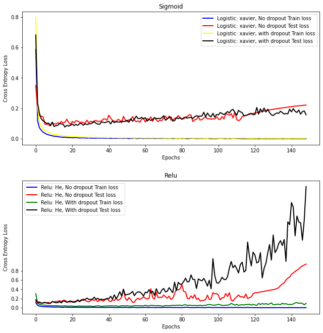

```python
# Plot graphs
import matplotlib.pyplot as plt
import numpy as np

fig, axes = plt.subplots(2, 1, figsize = (10,10) )
fig.tight_layout(pad=5.0)

for i in range(2):
    if(i == 0):
        ax = axes[i]
        # Doing MIN-MAX Scale to get from 0-1 range
        ax.plot(epochs_range, train_a, label = 'Logistic: xavier, No dropout Train loss', color="blue", linewidth=2 )

        ax.plot(epochs_range, test_loss_all_a_sigmoid, label = 'Logistic: xavier, No dropout Test loss', color="red", linewidth=2 )

        ax.plot(epochs_range, train_b, label = 'Logistic: xavier, with dropout Train loss', color="yellow", linewidth=2 )

        ax.plot(epochs_range, test_loss_all_b_sigmoid, label = 'Logistic: xavier, with dropout Test loss', color="black", linewidth=2 )

        ax.set_xlabel('Epochs')
        ax.set_ylabel('Cross Entropy Loss')
        ax.legend()
        ax.set_yticks(np.arange(0, 1, 0.2))
        ax.set_title('Sigmoid')

    if(i == 1):
        ax = axes[i]

        ax.plot(epochs_range, train_c, label = 'Relu: He, No dropout Train loss', color="blue", linewidth=2 )

        ax.plot(epochs_range, test_loss_all_c_relu, label = 'Relu: He, No dropout Test loss', color="red", linewidth=2 )

        ax.plot(epochs_range, train_d, label = 'Relu: He, With dropout Train loss', color="green", linewidth=2 )

        ax.plot(epochs_range, test_loss_all_d_relu, label = 'Relu: He, With dropout Test loss', color="black", linewidth=2 )

        ax.set_xlabel('Epochs')
        ax.set_ylabel('Cross Entropy Loss')
        ax.legend()
        ax.set_yticks(np.arange(0, 1, 0.2))
        ax.set_title('Relu')
```

```python
# # Sigmoid without dropout
# net = None
# net_a_sigmoid, _, valid_performance_a_sigmoid, train_loss_all_a_sigmoid, test_loss_all_a_sigmoid = create_and_run_network(init_type = 'xavier', activation_type = 'sigmoid', optimizer_choice = 'adam', lr = 0.01, dropout='no')
```

```python
# # Sigmoid with dropout
# net = None
# net_b_sigmoid, _, valid_performance_b_sigmoid, train_loss_all_b_sigmoid, test_loss_all_b_sigmoid = create_and_run_network(init_type = 'xavier', activation_type = 'sigmoid', optimizer_choice = 'adam', lr = 0.01, dropout='yes')
```

```python
# # Sigmoid with dropout
# net = None
# net_c_relu, _, valid_performance_c_relu, train_loss_all_c_relu, test_loss_all_c_relu = create_and_run_network(init_type = 'he', activation_type = 'relu', optimizer_choice = 'adam', lr = 0.01, dropout='no')
```

```python
# # Sigmoid with dropout
# net = None
# net_d_relu, _, valid_performance_d_relu, train_loss_all_d_relu, test_loss_all_d_relu = create_and_run_network(init_type = 'he', activation_type = 'relu', optimizer_choice = 'adam', lr = 0.01, dropout='yes')
```

```python
# epochs_range = [i for i in range(len(train_loss_all_a_sigmoid))]
# epochs_range[:10]
```

```python
# # Plot graphs
# import matplotlib.pyplot as plt
# import numpy as np

# fig, axes = plt.subplots(2, 1, figsize = (10,10) )
# fig.tight_layout(pad=5.0)

# for i in range(2):
#     if(i == 0):
#         ax = axes[i]
#         # Doing MIN-MAX Scale to get from 0-1 range
#         mm_vals = [ (xi - min(train_loss_all_a_sigmoid) )/ (max(train_loss_all_a_sigmoid) - min(train_loss_all_a_sigmoid)) for xi in train_loss_all_a_sigmoid]
#         ax.plot(epochs_range, mm_vals, label = 'Logistic: xavier, No dropout Train loss', color="blue", linewidth=2 )

#         mm_vals = [ (xi - min(test_loss_all_a_sigmoid) )/ (max(test_loss_all_a_sigmoid) - min(test_loss_all_a_sigmoid)) for xi in test_loss_all_a_sigmoid]
#         ax.plot(epochs_range, mm_vals, label = 'Logistic: xavier, No dropout Test loss', color="red", linewidth=2 )

#         mm_vals = [ (xi - min(train_loss_all_b_sigmoid) )/ (max(train_loss_all_b_sigmoid) - min(train_loss_all_b_sigmoid)) for xi in train_loss_all_b_sigmoid]
#         ax.plot(epochs_range, mm_vals, label = 'Logistic: xavier, with dropout Train loss', color="yellow", linewidth=2 )

#         mm_vals = [ (xi - min(test_loss_all_b_sigmoid) )/ (max(test_loss_all_b_sigmoid) - min(test_loss_all_b_sigmoid)) for xi in test_loss_all_b_sigmoid]
#         ax.plot(epochs_range, mm_vals, label = 'Logistic: xavier, with dropout Test loss', color="black", linewidth=2 )

#         ax.set_xlabel('Epochs')
#         ax.set_ylabel('Cross Entropy Loss')
#         ax.legend()
#         ax.set_yticks(np.arange(0, 1, 0.2))
#         ax.set_title('Sigmoid')

#     if(i == 1):
#         ax = axes[i]

#         mm_vals = [ (xi - min(train_loss_all_c_relu) )/ (max(train_loss_all_c_relu) - min(train_loss_all_c_relu)) for xi in train_loss_all_c_relu]
#         ax.plot(epochs_range, mm_vals, label = 'Relu: He, No dropout Train loss', color="blue", linewidth=2 )

#         mm_vals = [ (xi - min(test_loss_all_c_relu) )/ (max(test_loss_all_c_relu) - min(test_loss_all_c_relu)) for xi in test_loss_all_c_relu]
#         ax.plot(epochs_range, mm_vals, label = 'Relu: He, No dropout Test loss', color="red", linewidth=2 )

#         mm_vals = [ (xi - min(train_loss_all_d_relu) )/ (max(train_loss_all_d_relu) - min(train_loss_all_d_relu)) for xi in train_loss_all_d_relu]
#         ax.plot(epochs_range, mm_vals, label = 'Relu: He, With dropout Train loss', color="green", linewidth=2 )

#         mm_vals = [ (xi - min(test_loss_all_d_relu) )/ (max(test_loss_all_d_relu) - min(test_loss_all_d_relu)) for xi in test_loss_all_d_relu]
#         ax.plot(epochs_range, mm_vals, label = 'Relu: He, With dropout Test loss', color="black", linewidth=2 )

#         ax.set_xlabel('Epochs')
#         ax.set_ylabel('Cross Entropy Loss')
#         ax.legend()
#         ax.set_yticks(np.arange(0, 1, 0.2))
#         ax.set_title('Relu')
```